# Harmonization Simulation

Output/Simulations_2020-10-05_11-00-AM.html

# Simulation details

This simulation generates factor scores by fixing the item parameter estimates to their sample-estimated values (obtained from group 1 for linking items and the combined sample for non-linking items) and by fixing the metric to $N(0, 1)$.

10 scenarios are simulated. In the 9th and 10th, the estimates are manually overridden for two items to evaluate the performance of the harmonization when item difficulties are symmetrically distributed around 0 (9) and to use good discrimination parameters (10).

# Syntax

## Initialization

```r
# ----------------------------Set Simulation Options -----------------------------

Seed <- 21589
mus <- c(0, -0.24)
#sigmas <- c(sd_hrs, sd_mhas)
refGrp <- 1
repTheta <- 1
reps <- 500
fsMeth <- "EAP"
n1 <- 500
n2 <- 500
```

```r
# ----------------------------Initialize -----------------------------
# Load packages
library(pacman)
p_load(tidyverse, pander, readr, mirt, tidyr, ggplot2, lubridate,
       DT, RColorBrewer, ggthemes, officer, knitr, knitrProgressBar)
#source("~/Research/Code/runMplus.R")
#source("~/Research/Code/extractVarNames.R")
#source("Code/simulation_functions.R")

if(!dir.exists("Output")) {
  dir.create("Output")
}
outFolderName <- format(Sys.time(), "%Y-%m-%d_%I-%M-%p")
outPath <- file.path("Output", outFolderName)
dir.create(outPath)
logPath <- file.path(outPath, "Logs")
dir.create(logPath)
plotPath <- file.path(outPath, "Plots")
dir.create(plotPath)
resultsPath <- file.path(outPath, "Results")
dir.create(resultsPath)
```

## Functions

### extractDiffMatrix

```r
# ---------------------------- Define Functions -----------------------------
# extractDiffMatrix is used by equateSim and not called directly
extractDiffMatrix <- function(pars) {
  diff1 <- pars[grepl("d+", pars$name), c("item", "name", "value")]
  diff1$item <- as.character(diff1$item)
  diffsum <- diff1 %>% group_by(item) %>% summarise(ncat = sum(!is.na(item)))
  diff <- matrix(nrow = nrow(diffsum), ncol = max(diffsum$ncat))
  for (j in 1:nrow(diffsum)) {
    vals <- diff1[diff1$item %in% diffsum[j, "item"], "value"]
    if (length(vals) < max(diffsum$ncat)) {
      for (i in (length(vals) + 1):max(diffsum$ncat)) {
        vals[i] <- NA
      }
    }
    diff[j, ] <- vals
  }
  return(diff)
}
```

### equateSim

```r
# equateSim is a function the uses R mirt item response theory (IRT) methods
# to: 1) simulate item level datasets based on item parameters, 2) perform IRT
# calibrations on the simulated datasets, 3) estimate ability scores for each
# person in the simulated datasets, and 4) compute metrics to quantify the
# correspondence between the estimated ability from the simulated datasets and the
# true ability that was used to generate the simulations. Metrics include the
# root mean square error (RMSE), the mean of the estimated ability scores,
# the standard deviation of the estimated ability scores, and, optionally,
# the reliability of the estimated ability scores as measured by the agreement
# (Pearson's r or intra-class correlation) between the estimated ability scores
# and the data-generating theta values for each case. Multiple simulations
# of the same set of simulated true ability values can be generated (n_rep_theta).
#   This function simulates two groups that can differ in mean and standard
# deviation of simulated true ability, and different items can be used for each
# group as long as there is at least one common, linking item.
#
# Parameters:
#   seed - random seed for simulations (default=NULL)
#   grp_mean - true ability means of the two groups (default=c(0.5,-0.5))
#   grp_sd - true ability standard deviations of the two groups (default=c(1,1))
#   ref_grp - which group is used as the reference? 0 = no reference group, 1 = group 1, 2 = group 2
#   n_rep - number of simulated samples of true ability values (default=100)
#   n_rep_theta - number of repetitions of each simulated sample of true ability
#     values (default=1)
#   n_samp1 - sample size of group 1 in each simulation (default=500)
#   n_samp2 - sample size of group 2 in each simulation (default=500)
#   pars - mirt item parameters file (default=mcal_par)
#     A parameter file can be generated by:
#       mcal_par <- mirt(df,mdl,pars='values') where df is a dataframe with
#         item response data and mdl is a mirt model object. The returned file
#         (mcal_par in this example) can be edited to change item parameters.
#   n_rep - number of simulated samples of true ability values (default=100)
#   itms1 - list of items available for group 1 (default=item_list_1)
#   itms2 - list of items available for group 2 (default=item_list_2)
#   fsc_method - mirt method for calculating estimated ability values
#     (default="EAP")
#   mod_res_obj - mirt model results object from mirt analysis. This must
#     be from the same mirt model as pars.
#   save_sims - option to output simulated datasets (default=FALSE)
#   verbose - option to print (TRUE) or suppress (FALSE) messages (default = FALSE)
#   save_log - option to save a log of verbose output instead of printing to screen (default = TRUE)
#   log_file - name of log file to be saved. Default is paste0("technical_output_log_", format(Sys.time(), "%Y-%m-%d_%I-%M-%p"), ".txt")
#   prog_bar - option to show a progress bar on screen instead of verbose messages (default = TRUE)
#   rel - option to calculate reliability statistics for individual ability estimates (default = TRUE)
#   man_override - list of parameters and their values to manually override when performing the simulations. The default is NULL.
#     Three parameters must be specified in the list. These are:
#       1. iname - the name of the item(s) whose parameters will be fixed (character vector)
#       2. parameter - the name of the parameter to be fixed (character vector)
#         Options include:
#           "a1" - item discrimination
#           "d" - item easiness (the default in mirt) for a dichotomous indicator
#           "d1", "d2", ... "dk", item easiness (the default in mirt) thresholds where k is the number of thresholds for a polytomous item.
#           "b" - item difficulty (converted to easiness by this script for use in mirt) for a dichotomous indicator
#           "b1", "b2", ... "bk", item difficulty (converted to easiness by this script for use in mirt) thresholds where k is the number of thresholds for a polytomous item.
#       3. val - the numeric value of the parameter(s) to be fixed (numeric)
#     Example usage is as follows:
#         man_override = list(iname = c("UDAY", "UMON"),
#                           parameter = c("b", "b"),
#                           val = c(0, 1.928))
#   std_sample - option to standardize the harmonized factor scores with scaling based on the empirical sample data (default = FALSE, which uses population-based scaling)
#   std_ref - if std_sample = TRUE, this sets the reference group for scaling of the standardized factor scores.
#       Options are:
#           0 for combined sample
#           1 for group 1
#           2 for group 2
#           NULL (default)

# equateSim returns a list with 2 elements:
# 1. "summary" - a dataframe that has summary statistics (rmse, mean
# estimated ability, sd estimated ability, and, optionally, Pearson's r and ICC(C,1) reliability statistics)
# for each group and each simulated
# sample of true abilities (n_rep). These statistics are produced for raw
# estimated abilities and for estimated abilities on a metric transformed to
# match the true ability metric (default) or the metric scaled according
# to a reference sample's mean and standard deviation.
# 2. "datasets" (if save_sims=TRUE) - a long format dataframe that includes original and estimated
# theta scores, group assignment, sample number, and rep_theta number

equateSim <- function(seed = NULL,
                      grp_mean = c(0.5,-0.5),
                      grp_sd = c(1, 1),
                      ref_grp = 1,
                      n_samp1 = 500,
                      n_samp2 = 500,
                      n_rep_theta = 1,
                      pars = mcal_pars,
                      n_rep = 100,
                      itms1 = item_list_1,
                      itms2 = item_list_2,
                      fsc_method = "EAP",
                      mod_res_obj = NULL,
                      save_sims = FALSE,
                      verbose = FALSE,
                      save_log = TRUE,
                      log_file = paste0(outPath, "/Logs/technical_output_log_",
                                        outFolderName,
                                        ".txt"),
                      prog_bar = TRUE,
                      rel = TRUE,
                      man_override = NULL,
                      std_sample = FALSE,
                      std_ref = NULL) {
```

```r
  simBegin <- Sys.time()

  ### Begin initialize display settings
  if (prog_bar) {
    library(progress)
    if (verbose & !save_log) {
      warning(
        "Progress bar cannot be displayed if verbose == TRUE. A log file will be created to store verbose output."
      )
      save_log <- TRUE
    }
    # pb <- progress_bar$new(
    #   format = "  Simulating data [:bar] :current of :total (:percent) elapsed: :elapsed eta: :eta",
    #   total = n_rep,
    #   clear = FALSE,
    #   width = 80
    # )
    pb <- knitrProgressBar::progress_estimated(n_rep)
  }
  ### End initialize display settings

  ### Begin initialize logging of technical output
  if (save_log) {
    verbose <- TRUE
    options(max.print = 9999)
    sink(log_file)
    print(sys.call(which = 0L)) # Prints the function call
    print(mget(ls()[!(ls() == "pb")])) # prints the arguments passed to the equateSim function
  }
  ### End initialize logging of technical output

  ### Begin load required packages
  require(dplyr)
  require(tidyr)
  require(mirt)
  require(stringr)
  if (rel) require(irr) # load irr package if reliability statistics are requested.
  ### End load required packages

  ### Begin check to ensure objects passed to function are correctly specified.
  if (any(!is.character(itms1),!is.character(itms2))) {
    if (save_log) {
      print("Error: itms1 and itms2 should be character vectors.")
      sink()
    }
    stop("itms1 and itms2 should be character vectors.")
  } else if (!(ref_grp %in% 0:2)) {
    if (save_log) {
      print(
        "Error: Incorrectly specified reference group. ref_grp should be 0 for no reference group, 1 for group 1, or 2 for group 2."
      )
      sink()
      stop()
    }
    stop(
      "Incorrectly specified reference group. ref_grp should be 0 for no reference group, 1 for group 1, or 2 for group 2."
    )
  } else {
    ### End check to ensure objects passed to function are correctly specified.

    ### Begin initialize items, parameters, and model syntax
    n_itm <- length(union(itms1, itms2))
    link_itms <- dplyr::intersect(itms1, itms2)
    if (save_log) {
      cat("\n Group 1 Items: ", itms1)
      cat("\n Group 2 Items: ", itms2)
      cat("\n Linking Items: ", link_itms, "\n\n")
    }
    diff <- extractDiffMatrix(pars)
    disc <- pars[pars$name == "a1", "value"]
    itemtype <- as.character(pars[pars$name == "a1", "class"])
    model <- mirt.model(paste0("cog = 1-", n_itm))

    # If manual override is requested, this checks to see whether user-inputted data
    # is in the form of difficulty (b) parameters.
    # If so, this converts them to easiness (d) parameters for use in mirt
    # The conversion formula used is d = b/-a
    if (!is.null(man_override)) {
      for (p in 1:length(man_override$iname)) {
        # Convert b to d
        if (str_detect(man_override$parameter[p], "b")) {
          man_override$parameter[p] <- gsub("b", "d", man_override$parameter[p])
          man_override$val[p] <- man_override$val[p] / -coef(mod_res_obj)[[man_override$iname[p]]][1]
        }
      }
    }
    ### End initialize items, parameters, and model syntax

    ### Begin simulating, estimating factor scores, and generating summary data
    set.seed(seed)
    j <- 0
    while (j < n_rep) {
      j <- j + 1
      startj <- j # keep track of where j starts
      time <- Sys.time() # keep track of time simulation began
      theta1 <- data.frame(rnorm(n_samp1, grp_mean[1], grp_sd[1])) # simulate group 1 data
      names(theta1) <- "theta1"
      theta1$group <- 1
      theta2 <- data.frame(rnorm(n_samp2, grp_mean[2], grp_sd[2])) # simulate group 2 data
      names(theta2) <- "theta1"
      theta2$group <- 2
      theta1 <- rbind(theta1, theta2) # combine groups 1 and 2

      ### Begin data simulation
      ds <- list() # ds is used to store each replicate of a simulated data set for a given theta
      # (by default, only one replicate per theta (n_rep_theta) is simulated, so unless the user overrides this
      # setting, the length of ds will be 1).
      for (i in 1:n_rep_theta) {
        if (is.null(mod_res_obj)) {

          # ds2 contains the data simulated according to the specified parameters
          # Here, ds2 is created when no mod_res_obj is provided by the user.
          # Item parameters are taken from the mirt item parameters object passed to the pars argument
          ds2 <- data.frame(simdata(a = disc,
                                    d = diff,
                                    N = n_samp1 + n_samp2,
                                    Theta = as.matrix(theta1$theta1),
                                    itemtype = itemtype))
        } else {
          if (!is.null(man_override)) {
            # If manual override of at least one item parameter is requested, this
            # replaces the existing item parameters passed as part of the mod_res_obj
            # object with the user-specified parameters

            # Get the parameters from mod_res_obj
            sim_pars <- coef(mod_res_obj, simplify = TRUE)$items %>%
              data.frame() %>%
              mutate(item = rownames(.)) %>%
              pivot_longer(cols = names(dplyr::select(.,-item)))

            # For each user-specified parameter to be manually overridden, replace
            # the mod_res_obj parameters with the user-specified values
            for (p in 1:length(man_override$iname)) {
              sim_pars$value[sim_pars$item == man_override$iname[p] &
                               sim_pars$name == man_override$parameter[p]] <- man_override$val[p]
            }

            # Reshape easiness parameter data so the object matches the matrix format required by mirt
            sim_pars_d <- as_tibble(matrix(sim_pars$value[sim_pars$name %in% str_sort(unique(str_extract(pars$name, "^d[1-9]*")),
                                                                                      na_last = NA)],
                                           nrow = n_itm,
                                           byrow = TRUE)) %>%
              mutate(V1 = coalesce(V1, V2)) %>%
              dplyr::select(-V2) %>%
              data.matrix()
```

```r
            # ds2 contains the data simulated according to the specified parameters
            # Here, ds2 is created when mod_res_obj is provided by the user AND
            # when manual override of at least one parameter is requested.
            # These item parameters are taken from the mod_res_obj object
            # unless otherwise specified ing the man_override argument
            ds2 <- data.frame(simdata(
              a = sim_pars$value[sim_pars$name == "a1"],
              d = sim_pars_d,
              itemtype = itemtype,
              N = n_samp1 + n_samp2,
              Theta = as.matrix(theta1$theta1)))
          } else {

            # ds2 contains the data simulated according to the specified parameters
            # Here, ds2 is created when mod_res_obj is provided by the user AND
            # when manual override of at least one parameter is NOT requested.
            # These item parameters are taken from the mod_res_obj object
            ds2 <- data.frame(simdata(
              model = mod_res_obj,
              N = n_samp1 + n_samp2,
              Theta = as.matrix(theta1$theta1)
            ))
          }
        }

        names(ds2) <- unique(pars[!pars$item == "GROUP", "item"])
        ds2 <- cbind(theta1, ds2)

        # For each group, create missing data for items not administered to that group
        for (group in 1:2) {
          if (group == 1) {
            ds2[ds2$group == 1, !names(ds2) %in% c("theta1", "group", itms1)] <- NA
          } else {
            ds2[ds2$group == 2, !names(ds2) %in% c("theta1", "group", itms2)] <- NA
          }
        }
        ds[[i]] <- ds2
      }
      ### End data simulation

      ### Begin parameter estimation using simulated data
      #### First, estimate the item parameters in the reference group only (metric fixed to N(0, 1))
      #### Second, fix the item parameters obtained from step 1 and re-run the model in the full sample,
      ##### freely estimating the latent variable mean and variance.
      ##### This scales the metric according to the reference group.
      #### Third, fix all item parameter estimates, as well as the latent variable mean and standard deviation,
      ##### and run a model with no free parameters.
      ##### This model with no free parameters will be used to generate factor scores in the full sample.
      sim_summ <- list()
      dataset <- list()
      for (i in 1:length(ds)) {
        # capture errors due to not all response option occurring in simulated dataset
        pars1 <- tryCatch({
          # This gets the parameter structure for the full data set and saves it as pars1
          # Later, this parameter structure is modified when fixing parameters to the
          # values derived from the reference group (if applicable)
          # This does not do any parameter estimation.
          mirt(
            ds[[i]][, 3:(n_itm + 2)],
            model = model,
            pars = 'values',
            verbose = verbose,
            technical = list(
              warn = all(!prog_bar, verbose) ,
              message = all(!prog_bar, verbose)
            )
          )
        }, warning = function(w) {
          return("warning")
        }, error = function(e) {
          return("error")
        })

        # t1 <- dplyr::select(ds[[i]], names(ds[[i]])[3:(n_itm+2)])

        pars2 <- tryCatch({
          # This gets the parameter structure for the model when applied to the reference group (if applicable)
          # and saves it as pars2
          if (ref_grp == 0) {
            # No reference group (full sample)
            # This does not do any parameter estimation.
            mirt(
              dplyr::select(ds[[i]], names(ds[[i]])[3:(n_itm + 2)]),
              model = model,
              pars = 'values',
              verbose = verbose,
              technical = list(
                warn = all(!prog_bar, verbose),
                message = all(!prog_bar, verbose)
              )
            )
          } else if (ref_grp == 1) {
            # Reference group 1
            # This does not do any parameter estimation.
            mirt(
              dplyr::select(filter(ds[[i]], group == ref_grp), all_of(itms1)),
              model = mirt.model(paste0("cog = 1-", length(itms1))),
              pars = 'values',
              verbose = verbose,
              technical = list(
                warn = all(!prog_bar, verbose),
                message = all(!prog_bar, verbose)
              )
            )
          }  else if (ref_grp == 2) {
            # Reference group 2
            # This does not do any parameter estimation.
            mirt(
              dplyr::select(filter(ds[[i]], group == ref_grp), all_of(itms2)),
              model = mirt.model(paste0("cog = 1-", length(itms2))),
              pars = 'values',
              verbose = verbose,
              technical = list(
                warn = all(!prog_bar, verbose),
                message = all(!prog_bar, verbose)
              )
            )
          } else {
            stop(
              "Incorrectly specified reference group. ref_grp should be 0 for no reference group, 1 for group 1, or 2 for group 2."
            )
          }
        }, warning = function(w) {
          return("warning")
        }, error = function(e) {
          return("error")
        })

        if (is.data.frame(pars1) & is.data.frame(pars2)) {
          if (verbose) {
            cat("check 1 - pars1 and pars2 are dataframes\n")
          }
          if (nrow(pars1[pars1$item %in% link_itms, ]) ==
              nrow(pars2[pars2$item %in% link_itms, ])) {
            if (verbose) {
              cat(
                "check 2 - pars1 and pars2 linking items have the same number of parameters\n"
              )
            }
            # If a reference group is selected, this runs the model only on the simulated reference group data/items
            # to obtain difficulty and discrimination parameter estimates for the linking items
            # that are later applied as constraints in the full sample.
            if (ref_grp == 1) {
              # Reference group 1
              # This does parameter estimation in group 1 only.
              # The metric is set to the default N(0, 1). No other parameters are fixed here.
              mcal_rg <-
                mirt(
                  dplyr::select(filter(ds[[i]], group == ref_grp), all_of(itms1)),
                  model = mirt.model(paste0("cog = 1-", length(
                    itms1
                  ))),
                  pars = pars2,
                  verbose = verbose,
                  technical = list(
                    warn = all(!prog_bar, verbose),
                    message = all(!prog_bar, verbose)
                  )
                )
              if (verbose) {
                cat("calibration reference group = 1\n")
              }
            } else if (ref_grp == 2) {
              # Reference group 2
              # This does parameter estimation in group 2 only.
              # The metric is set to the default N(0, 1). No other parameters are fixed here.
              mcal_rg <-
                mirt(
                  dplyr::select(filter(ds[[i]], group == ref_grp), all_of(itms2)),
                  model = mirt.model(paste0("cog = 1-", length(
                    itms2
                  ))),
                  pars = pars2,
                  verbose = verbose,
                  technical = list(
                    warn = all(!prog_bar, verbose),
                    message = all(!prog_bar, verbose)
                  )
                )
              if (verbose) {
                cat("calibration reference group = 2\n")
              }
            } else if (ref_grp != 0) {
              stop(
                "Incorrectly specified reference group. ref_grp should be 0 for no reference group, 1 for group 1, or 2 for group 2."
              )
            }
```

```r
            if (ref_grp %in% 1:2) {
              # If parameter estimates were obtained for one of the reference groups,
              # constrain the linking item parameters here before estimating the models in the combined sample.

              for (itm in link_itms) {
                mcal_itm <- data.frame(coef(
                  mcal_rg,
                  IRTpars = FALSE,
                  simplify = TRUE
                )$items)[itm, ]

                if (!is.na(mcal_itm$d)) {
                  nthresh <- 1
                } else {
                  nthresh <- sum(!is.na(dplyr::select(
                    mcal_itm, starts_with("d")
                  )))
                }

                pars1$value[pars1$name == "a1" &
                              pars1$item %in% itm] <- mcal_itm[, "a1"]
                pars1$est[pars1$name == "a1" &
                            pars1$item %in% itm] <- FALSE

                for (threshn in 1:nthresh) {
                  if (nthresh == 1) {
                    pars1$value[pars1$name == "d" &
                                  pars1$item %in% itm] <-
                      mcal_itm[, "d"]
                    pars1$est[pars1$name == "d" &
                                pars1$item %in% itm] <- FALSE

                  } else if (nthresh > 1) {
                    pars1$value[pars1$name == paste0("d", threshn) &
                                  pars1$item %in% itm] <-
                      mcal_itm[, paste0("d", threshn)]
                    pars1$est[pars1$name == paste0("d", threshn) &
                                pars1$item %in% itm] <- FALSE

                  }
                }
              }
            }

            if (ref_grp %in% 1:2) {
              # If a reference group is used (item parameters are constrained), freely estimate the latent variable mean and variance.
              # This sets the metric based on the fixed parameter estimates.
              pars1$est[pars1$name == "MEAN_1"] <- TRUE
              pars1$est[pars1$name == "COV_11"] <- TRUE
              if (verbose) {
                cat(
                  "\n\nParameter table after fixing to values of chosen reference group\n\n"
                )
                print(pars1)
                cat("\n\n")
              }
            }

            # Now run the mirt model with either the linking items unconstrained (no reference group)
            # or constrained (to the values estimated in the reference group) models
            mcal <-
              mirt(
                ds[[i]][, 3:(n_itm + 2)],
                model = model,
                pars = pars1,
                verbose = verbose,
                technical = list(
                  warn = all(!prog_bar, verbose),
                  message = all(!prog_bar, verbose)
                )
              )

            ### End parameter estimation using simulated data

            ### Begin generating individual ability estimates (factor scores)
            # Then fix all of the parameters to their estimates and use this fully constrained model to estimate factor scores.

            mcal_pars <- data.frame(coef(mcal, IRTpars = FALSE,
                                         simplify = TRUE)$items) %>%
              mutate(item = rownames(.)) %>%
              pivot_longer(
                cols = -item,
                names_to = "name",
                values_to = "value",
                values_drop_na = TRUE
              )
            pars3 <- pars1
            pars3$value[1:nrow(mcal_pars)] <- mcal_pars$value
            pars3$est <- FALSE

            ## First option: fix M & SD to sample-estimated values
            #pars3$value[pars3$name == "MEAN_1"] <- coef(mcal)$GroupPars[1]
            #pars3$value[pars3$name == "COV_11"] <- coef(mcal)$GroupPars[2]

            ## Second option: fix M & SD to population values (M = 0, SD = 1)
            pars3$value[pars3$name == "MEAN_1"] <- 0
            pars3$value[pars3$name == "COV_11"] <- 1

            ## Third option: freely estimate M & SD
            #pars3$est[pars3$name == "MEAN_1"] <- TRUE
            #pars3$est[pars3$name == "COV_11"] <- TRUE

            fcmod <-
              mirt(
                ds[[i]][, 3:(n_itm + 2)],
                model = model,
                pars = pars3,
                verbose = verbose,
                technical = list(
                  warn = all(!prog_bar, verbose),
                  message = all(!prog_bar, verbose)
                )
              )

            if (verbose) {
              cat("calibration - final\n")
            }


            fsc <-
              data.frame(fscores(fcmod, full.scores = TRUE, method = fsc_method))
            names(fsc) <- "ability_est"
            t6 <- cbind(ds[[i]], fsc)
            # names(t6) <- sub("F1","ability_est",names(t6))
            names(t6) <- sub("theta1", "ability", names(t6))

            t6$ability_est <-
              ifelse(t6$ability_est %in% c(Inf, -Inf),
                     NA,
                     t6$ability_est)
            ### End generating individual ability estimates (factor scores)

            ### Begin standardizing factor scores and calculating unstandardized and standardized residuals
            t6$resid <- t6$ability_est - t6$ability

            if (std_sample) {
              # Standardized factor scores based on sample estimates
              if (std_ref == 0) {
                # standardize factor scores based on M and SD of full sample
                t6$abil_est_st <-
                  (t6$ability_est - mean(t6$ability_est, na.rm = TRUE)) / sd(t6$ability_est)
              } else {
                # standardize factor scores based on M and SD of chosen subgroup
                t6$abil_est_st <-
                  (t6$ability_est - mean(t6$ability_est[t6$group == std_ref], na.rm = TRUE)) /
                  sd(t6$ability_est[t6$group == std_ref])
              }
            } else {
              # Standardized factor scores informed by population parameters
              t6$abil_est_st <-
                (t6$ability_est - mean(t6$ability_est, na.rm = TRUE)) *
                (sd(t6$ability) / sd(t6$ability_est, na.rm = TRUE)) +
                mean(t6$ability) # linear equating to true ability metric
            }
```

```r
            t6$resid_st <- t6$abil_est_st - t6$ability
            ### End standardizing factor scores and calculating unstandardized and standardized residuals

            t6$sample <- j
            t6$rep_theta <- i


            sim_summ[[i]] <-
              t6[, c("ability",
                     "ability_est",
                     "resid",
                     "abil_est_st",
                     "resid_st",
                     "group")]

            if (save_sims == TRUE) {
              if (j == 1 & i == 1) {
                sim_data <- t6
              } else {
                sim_data <- rbind(sim_data, t6)
              }
            }
          } else {
            if (verbose) {
              cat(
                "check 3 - pars1 and pars2 linking items have different numbers of parameters\n"
              )
            }
            j <- j - 1
          }
        } else {
          if (verbose) {
            cat("check 4 - pars1 or pars2 are not dataframes\n")
          }
          j <- j - 1
        }
      }
      ### This code block can be modified to output true ability, estimated
      #   ability, and simulated datasets
      # abil <- data.frame(matrix(ncol = length(sim_summ), nrow = 500))
      # abil_est <- data.frame(matrix(ncol = length(sim_summ), nrow = 500))
      # res <- data.frame(matrix(ncol = length(sim_summ), nrow = 500))
      if (j == startj) {
        # don't do these calculations and compile the data if j was reduced by 1
        # due to failed checks.
        stat <-
          data.frame(matrix(nrow = 12, ncol = length(sim_summ)))
        if (length(sim_summ) > 0) {
          for (i in 1:length(sim_summ)) {
            nm <- paste("dset_", i, sep = "")
            # abil[,i] <- sim_summ[[i]]$ability
            # names(abil)[i] <- nm
            # abil_est[,i] <- sim_summ[[i]]$abil_est_st
            # names(abil_est)[i] <- nm
            # res[,i] <- sim_summ[[i]]$resid_st
            # names(res)[i] <- nm
            df <- sim_summ[[i]]
            stat[1, i] <-
              sqrt(mean(df[df$group == 1, "resid"] ^ 2, na.rm = TRUE))
            stat[2, i] <-
              sqrt(mean(df[df$group == 2, "resid"] ^ 2, na.rm = TRUE))
            stat[3, i] <-
              sqrt(mean(df[df$group == 1, "resid_st"] ^ 2, na.rm = TRUE))
            stat[4, i] <-
              sqrt(mean(df[df$group == 2, "resid_st"] ^ 2, na.rm = TRUE))
            stat[5, i] <-
              mean(df[df$group == 1, "ability_est"], na.rm = TRUE)
            stat[6, i] <-
              mean(df[df$group == 2, "ability_est"], na.rm = TRUE)
            stat[7, i] <-
              mean(df[df$group == 1, "abil_est_st"], na.rm = TRUE)
            stat[8, i] <-
              mean(df[df$group == 2, "abil_est_st"], na.rm = TRUE)
            stat[9, i] <-
              sd(df[df$group == 1, "ability_est"], na.rm = TRUE)
            stat[10, i] <-
              sd(df[df$group == 2, "ability_est"], na.rm = TRUE)
            stat[11, i] <-
              sd(df[df$group == 1, "abil_est_st"], na.rm = TRUE)
            stat[12, i] <-
              sd(df[df$group == 2, "abil_est_st"], na.rm = TRUE)
            stat[13, i] <- sqrt(mean(df[, "resid"] ^ 2, na.rm = TRUE))
            stat[14, i] <- sqrt(mean(df[, "resid_st"] ^ 2, na.rm = TRUE))
            stat[15, i] <- mean(df[, "ability_est"], na.rm = TRUE)
            stat[16, i] <- mean(df[, "abil_est_st"], na.rm = TRUE)
            stat[17, i] <- sd(df[, "ability_est"], na.rm = TRUE)
            stat[18, i] <- sd(df[, "abil_est_st"], na.rm = TRUE)
            stat[19, i] <- grp_mean[1]
            stat[20, i] <- grp_mean[2]
            stat[21, i] <-
              weighted.mean(grp_mean, c(n_samp1, n_samp2))


            if (rel) {
              # Playing around with some different reliability statistics.
              stat[22, i] <-
                cor.test(df$ability[df$group == 1], df$ability_est[df$group == 1])$estimate
              stat[23, i] <-
                cor.test(df$ability[df$group == 2], df$ability_est[df$group == 2])$estimate
              stat[24, i] <-
                cor.test(df$ability, df$ability_est)$estimate
              stat[25, i] <-
                icc(df[df$group == 1, c("ability", "ability_est")],
                    model = "twoway",
                    type = "consistency",
                    unit = "single")$value # ICC(C,1)
              stat[26, i] <-
                icc(df[df$group == 2, c("ability", "ability_est")],
                    model = "twoway",
                    type = "consistency",
                    unit = "single")$value # ICC(C,1)
              stat[27, i] <-
                icc(df[c("ability", "ability_est")],
                    model = "twoway",
                    type = "consistency",
                    unit = "single")$value # ICC(C,1)
            }

            names(stat)[i] <- nm

            if (rel) {
              stat[c(1, 3, 5, 7, 9, 11, 19, 22, 25), "group"] <- 1
              stat[c(2, 4, 6, 8, 10, 12, 20, 23, 26), "group"] <- 2
              stat[c(13:18, 21, 24, 27), "group"] <- 0
              stat[c(1, 2, 5, 6, 9, 10, 13, 15, 17, 19:27), "type"] <-
                "raw"
              stat[c(3, 4, 7, 8, 11, 12, 14, 16, 18), "type"] <-
                "standardized"
              stat[c(1:4, 13:14), "statistic"] <- "rmse"
              stat[c(5:8, 15:16), "statistic"] <- "est_mean"
              stat[c(9:12, 17:18), "statistic"] <- "est_sd"
              stat[c(19:21), "statistic"] <- "theta"
              stat[c(22:24), "statistic"] <- "r_theta_est"
              stat[c(25:27), "statistic"] <- "ICC_C_1"
            } else {
              stat[c(1, 3, 5, 7, 9, 11, 19), "group"] <- 1
              stat[c(2, 4, 6, 8, 10, 12, 20), "group"] <- 2
              stat[c(13:18, 21), "group"] <- 0
              stat[c(1, 2, 5, 6, 9, 10, 13, 15, 17, 19:21), "type"] <-
                "raw"
              stat[c(3, 4, 7, 8, 11, 12, 14, 16, 18), "type"] <-
                "standardized"
              stat[c(1:4, 13:14), "statistic"] <- "rmse"
              stat[c(5:8, 15:16), "statistic"] <- "est_mean"
              stat[c(9:12, 17:18), "statistic"] <- "est_sd"
              stat[c(19:21), "statistic"] <- "theta"
            }
```

```r
            stat$samp_num <- j
          } # end for i
        }
        if (j > 0) {
          if (j == 1) {
            stat_summ <- stat
          } else {
            stat_summ <- rbind(stat_summ, stat)
          }
        }
        if (verbose) {
          cat(
            paste(
              " ############################# Iteration - ",
              j,
              " of ",
              n_rep,
              ". Elapsed time: ",
              Sys.time() - time,
              "\n",
              sep = ""
            )
          )
        }
        if (prog_bar)
          pb$tick()$print()
      }
    } # end while j
    if (n_rep_theta == 1) {
      stat_summ$avg <- stat_summ$dset_1
    } else {
      stat_summ$avg <- apply(stat_summ[, 1:n_rep], 1, mean)
    }
    sim_results <- list()
    sim_results[["summary"]] <- stat_summ
    if (save_sims == TRUE) {
      vnms <- c(
        "ability",
        "ability_est",
        "resid",
        "abil_est_st",
        "resid_st",
        "group",
        "sample",
        "rep_theta"
      )
      itnms <- names(sim_data[!names(sim_data) %in% vnms])
      sim_results[["datasets"]] <- sim_data[, c(vnms, itnms)]
    }
    if (save_log)
      simEnd <- Sys.time()
      runTime <- simEnd - simBegin
      cat("\n\n Total time to run scenario:", runTime)
      sink()
    return(sim_results)
  }
  closeAllConnections()
}
```

### infoSim

```r
# infoSim is a function that uses R mirt item response theory (IRT) methods
# to: 1) simulate an item level dataset based on item parameters, 2) perform an IRT
# calibrations on the simulated dataset, and 3) calculate test information values
# across a range of ability values. It estimates test information for two groups
# that can have different distributions of ability, and different items can be
# used for the two groups.

# Parameters:
#   seed - random seed for simulations (default=NULL)
#   grp_mean - true ability means of the two groups (default=c(0.5,-0.5))
#   grp_sd - true ability standard deviations of the two groups (default=c(1,1))
#   n_samp - sample size of each group in each simulation (default=500)
#   pars - mirt item parameters file (default=mcal_par)
#     A parameter file can be generated by:
# #       mcal_par <- mirt(df,mdl,pars='values') where df is a dataframe with
# #         item response data and mdl is a mirt model object. The returned file
# #         (mcal_par in this example) can be edited to change item parameters.
# #   itms1 - list of items available for group 1 (default=item_list_1)
# #   itms2 - list of items available for group 2 (default=item_list_2)
# This function returns a dataframe with ability values and corresponding test
# information values. This dataset can be use to graph a test information curve.

infoSim <- function(seed = NULL,
                    grp_mean = c(0.5, -0.5),
                    grp_sd = c(1, 1),
                    n_samp = 500,
                    pars = mcal_par,
                    itms1 = item_list_1,
                    itms2 = item_list_2) {
  diff <- pars[pars$name == "d", "value"]
  disc <- pars[pars$name == "a1", "value"]
  n_itm <- nrow(pars[pars$name == 'a1', ])
  links <- intersect(itms1, itms2)
  set.seed(seed)

  theta1 <- data.frame(rnorm(n_samp, grp_mean[1], grp_sd[1]))
  names(theta1) <- "theta1"
  theta1$group <- 1
  theta2 <- data.frame(rnorm(n_samp, grp_mean[2], grp_sd[2]))
  names(theta2) <- "theta1"
  theta2$group <- 2
  theta1 <- rbind(theta1, theta2)

  ds <-
    data.frame(simdata(
      disc,
      diff,
      n_samp,
      Theta = as.matrix(theta1$theta1),
      itemtype = '2PL'
    ))
  names(ds) <- unique(pars[!pars$item == "GROUP", "item"])
  ds <- cbind(theta1, ds)

  for (group in 1:2) {
    if (group == 1) {
      ds[ds$group == 1, !names(ds) %in% c("theta1", "group", itms1)] <- NA
    } else {
      ds[ds$group == 2, !names(ds) %in% c("theta1", "group", itms2)] <- NA
    }
  }

  pars1 <- pars[pars$item %in% c(itms1, "GROUP"), ]
  pars1$parnum <- 1:nrow(pars1)
  pars1[pars1$name == "d" & !pars1$item %in% links, "est"] <- TRUE
  pars1[pars1$name == "a1" & !pars1$item %in% links, "est"] <- TRUE

  pars2 <- pars[pars$item %in% c(itms2, "GROUP"), ]
  pars2$parnum <- 1:nrow(pars2)
  pars2[pars2$name == "d" & !pars2$item %in% links, "est"] <- TRUE
  pars2[pars2$name == "a1" & !pars2$item %in% links, "est"] <- TRUE

  n_itm_1 <- nrow(pars1[pars1$name == 'a1', ])
  n_itm_2 <- nrow(pars2[pars2$name == 'a1', ])

  mdl1 <- mirt.model(paste("cog = 1-", n_itm_1, sep = ""))
  mdl2 <- mirt.model(paste("cog = 1-", n_itm_2, sep = ""))


  Theta <- matrix(seq(-4, 4, by = .1))

  mcal1 <- mirt(ds[ds$group %in% 1, names(ds) %in% itms1],
                model = mdl1,
                modelitemtype = '2PL',
                pars = pars1)
  mcal2 <- mirt(ds[ds$group %in% 2, names(ds) %in% itms2],
                model = mdl2,
                modelitemtype = '2PL',
                pars = pars2)
  tinfo1 <- testinfo(mcal1, Theta)
  tinfo2 <- testinfo(mcal2, Theta)
  tinfo <- data.frame(cbind(Theta, tinfo1, tinfo2))
  names(tinfo) <- c("ability", "info_1", "info_2")

  return(tinfo)
}
```

### infoCalc

```r
# infoCalc is a function that generates test information values for a range of
# abilities based on a mirt results object (mirt_model_obj). It returns a
# dataframe with ability values and corresponding test information values.
# This dataset can be use to graph a test information curve.

infoCalc <- function(mirt_mod_obj) {
  theta <- matrix(seq(-4, 4, by = .1))
  tinfo <- testinfo(mirt_mod_obj, theta)
  tinfo <- data.frame(cbind(theta, tinfo))
  names(tinfo) <- c("ability", "information")

  return(tinfo)
}
```

### summaryStats

```r
# summaryStats is a function that calculates means and other performance metrics
# across simulated datasets of summary statistics (rmse, rmse_st, mean, mean_st, sd sd_st)
# returned by equateSim.
#
# Parameters:
#   df - data.frame of summary statistics for each simulated dataset returned
#     by equateSim
#
# summaryStats returns a dataframe with the means across simulated datasets of
# rmse, rmse_st, mean, mean_st, and sd sd_st for each group as well as the
# simple average of both groups. It includes a group variable (Group 1,
# Group 2, Combined)

summaryStats <- function(df) {
  library(tidyverse)
  df$label <- df$statistic
  df$label[df$type == "standardized"] <-
    df$label[df$type == "standardized"] %>%
    paste0(., "_st")
  df$label <- df$label %>%
    gsub("est_", "", ., fixed = TRUE)

  sumout <- df %>%
    group_by(group, label) %>%
    summarise(value = mean(avg)) %>%
    pivot_wider(names_from = label, values_from = value)

  # Not run: calculate confidence intervals for the means
  # ciM <- df %>%
  #   filter(statistic == "est_mean") %>%
  #   group_by(group, label) %>%
  #   summarise(lowCI = quantile(avg, (1-ci)/2),
  #             upCI = quantile(avg, (1+ci)/2)) %>%
  #   rename_at(c("lowCI", "upCI"), list(~paste0(., 100*ci, "m"))) %>%
  #   pivot_wider(names_from = label, values_from = names(.)[3:4])
  #
  # sumout <- left_join(sumout, ciM, by = "group")

  # Calculate the empirical standard error for the means
  ese <- df %>%
    filter(statistic == "est_mean") %>%
    group_by(group, label) %>%
    summarise(ese = sd(avg)) %>%
    pivot_wider(names_from = label, values_from = ese) %>%
    rename(ese = mean, ese_st = mean_st)

  sumout <- left_join(sumout, ese, by = "group")

  sumout$group <-
    car::recode(sumout$group, '0="Combined"; 1 = "Group 1"; 2 = "Group 2"')
  sumout <- sumout[c(2, 3, 1), ]

  # Calculate relative bias in the unstandardized grand means.
  # Constant of 1 added for Group 1, whose population mean is 0.
  sumout$bias <- NA
  sumout$bias_pct <- NA

  for (i in 1:nrow(sumout)) {
    sumout$bias[i] <-
      sumout$mean[i] - sumout$theta[i]
    sumout$bias_pct[i] <-
      (sumout$mean[i] - sumout$theta[i]) / abs(sumout$theta[i])
  }


  # Calculate relative bias in the standardized grand means.
  # Constant of 1 added for Group 1, whose population mean is 0.
  sumout$bias_st <- NA
  sumout$bias_pct_st <- NA

  for (i in 1:nrow(sumout)) {
    sumout$bias_st[i] <-
      sumout$mean_st[i] - sumout$theta[i]
    sumout$bias_pct_st[i] <-
      (sumout$mean_st[i] - sumout$theta[i]) / abs(sumout$theta[i])
  }


  sumout$n_rep <- length(unique(df$samp_num))
  sumout <- sumout %>%
    dplyr::select(
      group,
      theta,
      starts_with("mean"),
      starts_with("sd"),
      starts_with("rmse"),
      starts_with("ese"),
      starts_with("bias"),
      everything()
    )

  return(sumout)


  # rmse_grp_1 <- mean(df[df$group == 1 & df$type == "raw" &
  #                         df$statistic == "rmse","avg"])
  # rmse_grp_2 <- mean(df[df$group == 2 & df$type == "raw" &
  #                         df$statistic == "rmse","avg"])
  # rmse_grp_0 <- mean(df[df$group == 0 & df$type == "raw" &
  #                         df$statistic == "rmse","avg"])
  # rmse_st_grp_1 <- mean(df[df$group == 1 & df$type == "standardized" &
  #                            df$statistic == "rmse","avg"])
  # rmse_st_grp_2 <- mean(df[df$group == 2 & df$type == "standardized" &
  #                            df$statistic == "rmse","avg"])
  # rmse_st_grp_0 <- mean(df[df$group == 0 & df$type == "standardized" &
  #                            df$statistic == "rmse","avg"])
  # mean_grp_1 <- mean(df[df$group == 1 & df$type == "raw" &
  #                         df$statistic == "est_mean","avg"])
  # mean_grp_2 <- mean(df[df$group == 2 & df$type == "raw" &
  #                         df$statistic == "est_mean","avg"])
  # mean_grp_0 <- mean(df[df$group == 0 & df$type == "raw" &
  #                         df$statistic == "est_mean","avg"])
  # mean_st_grp_1 <- mean(df[df$group == 1 & df$type == "standardized" &
  #                            df$statistic == "est_mean","avg"])
  # mean_st_grp_2 <- mean(df[df$group == 2 & df$type == "standardized" &
  #                            df$statistic == "est_mean","avg"])
  # mean_st_grp_0 <- mean(df[df$group == 0 & df$type == "standardized" &
  #                            df$statistic == "est_mean","avg"])
  # sd_grp_1 <- mean(df[df$group == 1 & df$type == "raw" &
  #                       df$statistic == "est_sd","avg"])
  # sd_grp_2 <- mean(df[df$group == 2 & df$type == "raw" &
  #                       df$statistic == "est_sd","avg"])
  # sd_grp_0 <- mean(df[df$group == 0 & df$type == "raw" &
  #                       df$statistic == "est_sd","avg"])
  # sd_st_grp_1 <- mean(df[df$group == 1 & df$type == "standardized" &
  #                          df$statistic == "est_sd","avg"])
  # sd_st_grp_2 <- mean(df[df$group == 2 & df$type == "standardized" &
  #                          df$statistic == "est_sd","avg"])
  # sd_st_grp_0 <- mean(df[df$group == 0 & df$type == "standardized" &
  #                          df$statistic == "est_sd","avg"])
  # # rmse12 <- mean(rmse_grp_1,rmse_grp_2)
  # # rmse_st12 <- mean(rmse_st_grp_1,rmse_st_grp_2)
  # # mean12 <- mean(mean_grp_1,mean_grp_2)
  # # mean_st12 <- mean(mean_st_grp_1,mean_st_grp_2)
  # # sd12 <- mean(sd_grp_1,sd_grp_2)
  # # sd_st12 <- mean(sd_st_grp_1,sd_st_grp_2)
  #
  # nms <- c("rmse","rmse_st","mean","mean_st","sd","sd_st")
  # stat_1 <- data.frame(cbind(rmse_grp_1,rmse_st_grp_1,mean_grp_1,mean_st_grp_1,
  #                            sd_grp_1,sd_st_grp_1))
  # names(stat_1) <- nms
  # stat_1$group <- 1
  # stat_2 <- data.frame(cbind(rmse_grp_2,rmse_st_grp_2,mean_grp_2,mean_st_grp_2,
  #                            sd_grp_2,sd_st_grp_2))
  # names(stat_2) <- nms
  # stat_2$group <- 2
  # stat_12 <- data.frame(cbind(rmse_grp_0,rmse_st_grp_0,mean_grp_0,mean_st_grp_0,
  #                             sd_grp_0,sd_st_grp_0))
  # names(stat_12) <- nms
  # stat_12$group <- 0
  #
  # stat <- rbind(stat_1,stat_2,stat_12)
  # stat$group <- factor(stat$group,levels=c(0,1,2),
  #                      labels=c("Combined","Group 1","Group 2"))
  # return(stat)
}
```

## Calibration

```r
# *********************** mirt calibration of PITCH TICS ***********************

### mirt calibration of tics

# input PITCH tics dataset
tics <- read.csv("Data/PITCH-response-data-fhl.csv")

# HRS items
vars <- c('UBAK','UDAT','UDAY','UDWR','UIWR','UMON','UNM1','UNM2','UNM5','UNM6',
          'USUB','UYER')
# MHAS items
varsm <- c("UDAY","UFCO2","UFRE1","UMON","UVSC","UWD","UWR1","UWR2","UWR3","UYER")

# select HRS items and persons
hrs <- tics[tics$study_name_short %in% c("HRS_CODA_W6","HRS_W6"),c("newid",
                                                                   "study_wave_number","study_name_short",vars)]
hrs$n_itm <- apply(hrs[,vars],1,function(x) sum(!is.na(x)))
hrs <- hrs[!hrs$n_itm ==0,]

m1hrs <- mirt.model('cog = 1-12') # creates mirt model object
hrs_par <- mirt(hrs[,vars],m1hrs,pars='values') # generates item parameters file that can be edited to guide further analyses

hrscal <- mirt(hrs[,vars],m1hrs,pars=hrs_par) # IRT calibration
```

```
##
Iteration: 1, Log-Lik: -111928.037, Max-Change: 2.27949
Iteration: 2, Log-Lik: -108633.355, Max-Change: 1.21871
Iteration: 3, Log-Lik: -106845.807, Max-Change: 1.01232
Iteration: 4, Log-Lik: -105892.216, Max-Change: 1.14507
Iteration: 5, Log-Lik: -105126.057, Max-Change: 0.87762
Iteration: 6, Log-Lik: -104852.156, Max-Change: 0.62611
Iteration: 7, Log-Lik: -104686.042, Max-Change: 0.59372
Iteration: 8, Log-Lik: -104547.196, Max-Change: 0.37954
Iteration: 9, Log-Lik: -104509.662, Max-Change: 0.25161
Iteration: 10, Log-Lik: -104493.882, Max-Change: 0.15021
Iteration: 11, Log-Lik: -104484.194, Max-Change: 0.04976
Iteration: 12, Log-Lik: -104475.155, Max-Change: 0.10627
Iteration: 13, Log-Lik: -104471.943, Max-Change: 0.10315
Iteration: 14, Log-Lik: -104469.723, Max-Change: 0.05354
Iteration: 15, Log-Lik: -104468.046, Max-Change: 0.02261
Iteration: 16, Log-Lik: -104465.715, Max-Change: 0.03233
Iteration: 17, Log-Lik: -104463.820, Max-Change: 0.01109
Iteration: 18, Log-Lik: -104463.128, Max-Change: 0.01637
Iteration: 19, Log-Lik: -104462.565, Max-Change: 0.00588
Iteration: 20, Log-Lik: -104462.351, Max-Change: 0.00574
Iteration: 21, Log-Lik: -104462.187, Max-Change: 0.00348
Iteration: 22, Log-Lik: -104462.112, Max-Change: 0.00373
Iteration: 23, Log-Lik: -104462.030, Max-Change: 0.00219
Iteration: 24, Log-Lik: -104461.984, Max-Change: 0.02066
Iteration: 25, Log-Lik: -104461.902, Max-Change: 0.00256
Iteration: 26, Log-Lik: -104461.868, Max-Change: 0.00165
Iteration: 27, Log-Lik: -104461.849, Max-Change: 0.00197
Iteration: 28, Log-Lik: -104461.831, Max-Change: 0.01176
Iteration: 29, Log-Lik: -104461.792, Max-Change: 0.00253
Iteration: 30, Log-Lik: -104461.788, Max-Change: 0.00048
Iteration: 31, Log-Lik: -104461.787, Max-Change: 0.00026
Iteration: 32, Log-Lik: -104461.785, Max-Change: 0.00026
Iteration: 33, Log-Lik: -104461.784, Max-Change: 0.00008
```

```r
# coef(hrscal)
# coef(hrscal, IRTpars = TRUE)

m2hrs <- mirt.model('cog = 1-11')

# HRS calibration excluding delayed word recall
hrs_par_0dr <- mirt(hrs[,vars[!vars %in% "UDWR"]],m2hrs,pars='values')
hrscal_0dr <- mirt(hrs[,vars[!vars %in% "UDWR"]],m2hrs,pars=hrs_par_0dr)
```

```
##
Iteration: 1, Log-Lik: -80935.243, Max-Change: 1.57580
Iteration: 2, Log-Lik: -79811.967, Max-Change: 0.50476
Iteration: 3, Log-Lik: -79621.592, Max-Change: 0.39486
Iteration: 4, Log-Lik: -79519.691, Max-Change: 0.20910
Iteration: 5, Log-Lik: -79477.758, Max-Change: 0.17943
Iteration: 6, Log-Lik: -79451.114, Max-Change: 0.10016
Iteration: 7, Log-Lik: -79433.267, Max-Change: 0.04746
Iteration: 8, Log-Lik: -79424.291, Max-Change: 0.03439
Iteration: 9, Log-Lik: -79418.602, Max-Change: 0.07186
Iteration: 10, Log-Lik: -79408.948, Max-Change: 0.03062
Iteration: 11, Log-Lik: -79407.084, Max-Change: 0.02384
Iteration: 12, Log-Lik: -79405.876, Max-Change: 0.02305
Iteration: 13, Log-Lik: -79405.360, Max-Change: 0.00652
Iteration: 14, Log-Lik: -79405.153, Max-Change: 0.00521
Iteration: 15, Log-Lik: -79405.025, Max-Change: 0.00607
Iteration: 16, Log-Lik: -79404.771, Max-Change: 0.00100
Iteration: 17, Log-Lik: -79404.764, Max-Change: 0.00073
Iteration: 18, Log-Lik: -79404.756, Max-Change: 0.00075
Iteration: 19, Log-Lik: -79404.754, Max-Change: 0.00031
Iteration: 20, Log-Lik: -79404.753, Max-Change: 0.00040
Iteration: 21, Log-Lik: -79404.752, Max-Change: 0.00022
Iteration: 22, Log-Lik: -79404.752, Max-Change: 0.00018
Iteration: 23, Log-Lik: -79404.752, Max-Change: 0.00030
Iteration: 24, Log-Lik: -79404.751, Max-Change: 0.00009
```

```r
# HRS calibration excluding immediate word recall
hrs_par_0ir <- mirt(hrs[,vars[!vars %in% "UIWR"]],m2hrs,pars='values',
                    technical=list(removeEmptyRows=TRUE))
hrscal_0ir <- mirt(hrs[,vars[!vars %in% "UIWR"]],m2hrs,pars=hrs_par_0ir,
                   technical=list(removeEmptyRows=TRUE))
```

```
##
Iteration: 1, Log-Lik: -82183.632, Max-Change: 1.71471
Iteration: 2, Log-Lik: -80450.949, Max-Change: 0.80508
Iteration: 3, Log-Lik: -80121.959, Max-Change: 0.25270
Iteration: 4, Log-Lik: -80010.923, Max-Change: 0.30971
Iteration: 5, Log-Lik: -79981.252, Max-Change: 0.19185
Iteration: 6, Log-Lik: -79972.145, Max-Change: 0.11751
Iteration: 7, Log-Lik: -79968.199, Max-Change: 0.07085
Iteration: 8, Log-Lik: -79966.330, Max-Change: 0.02168
Iteration: 9, Log-Lik: -79965.413, Max-Change: 0.04092
Iteration: 10, Log-Lik: -79964.892, Max-Change: 0.00685
Iteration: 11, Log-Lik: -79964.737, Max-Change: 0.00357
Iteration: 12, Log-Lik: -79964.677, Max-Change: 0.00290
Iteration: 13, Log-Lik: -79964.611, Max-Change: 0.00079
Iteration: 14, Log-Lik: -79964.607, Max-Change: 0.00014
Iteration: 15, Log-Lik: -79964.606, Max-Change: 0.00031
Iteration: 16, Log-Lik: -79964.606, Max-Change: 0.00019
Iteration: 17, Log-Lik: -79964.605, Max-Change: 0.00008
```

```r
# coef(hrscal_0ir)

#  mirt calibration of MHAS

mex <- tics[tics$study_name_short %in% c("MHAS_W1","MHAS_W2"),c("newid",
                                                                "study_wave_number","study_name_short",varsm)]
mex$n_itm <- apply(mex[,varsm],1,function(x) sum(!is.na(x)))
mex <- mex[!mex$n_itm ==0,]

m1mex <- mirt.model('cog = 1-10')
mex_par <- mirt(mex[,varsm],m1mex,pars='values')

mexcal <- mirt(mex[,varsm],m1mex,pars=mex_par)
```

[output not shown]

```r
# coef(mexcal)

#  mirt calibration of combined HRS and MHAS

hrme <- tics[tics$study_name_short %in% c("HRS_CODA_W6","HRS_W6") |
               tics$study_name_short %in% c("MHAS_W1","MHAS_W2"),c("newid",
                                                                   "study_wave_number","study_name_short",union(vars,varsm))]
hrme$n_itm <- apply(hrme[,union(vars,varsm)],1,function(x) sum(!is.na(x)))
hrme <- hrme[!hrme$n_itm == 0,]

m1hrme <- mirt.model('cog = 1-19')
hrme_par <- mirt(hrme[,union(vars,varsm)],m1hrme,pars='values')


hrmecal <- mirt(data = hrme[,union(vars,varsm)], model = m1hrme, pars = hrme_par)
```

[output not shown]

[output cut: 22 more lines]

```
Iteration: 62, Log-Lik: -375530.826, Max-Change: 0.00034
Iteration: 63, Log-Lik: -375530.824, Max-Change: 0.00020
Iteration: 64, Log-Lik: -375530.823, Max-Change: 0.00029
Iteration: 65, Log-Lik: -375530.820, Max-Change: 0.00033
Iteration: 66, Log-Lik: -375530.818, Max-Change: 0.00020
Iteration: 67, Log-Lik: -375530.817, Max-Change: 0.00029
Iteration: 68, Log-Lik: -375530.814, Max-Change: 0.00034
Iteration: 69, Log-Lik: -375530.813, Max-Change: 0.00020
Iteration: 70, Log-Lik: -375530.812, Max-Change: 0.00031
Iteration: 71, Log-Lik: -375530.809, Max-Change: 0.00037
Iteration: 72, Log-Lik: -375530.808, Max-Change: 0.00022
Iteration: 73, Log-Lik: -375530.807, Max-Change: 0.00036
Iteration: 74, Log-Lik: -375530.805, Max-Change: 0.00045
Iteration: 75, Log-Lik: -375530.803, Max-Change: 0.00027
Iteration: 76, Log-Lik: -375530.802, Max-Change: 0.00009
```

```r
# hrmecal <- mirt(hrme[,union(vars,varsm)],m1hrme)
# coef(hrmecal)
# parameters(hrmecal)

# coef(hrmecal, IRTpars = TRUE, simplify = TRUE)$items %>%
#   DT::datatable(options = list(pageLength = 19), rownames = TRUE) %>%
#   formatRound(columns = 1:13, digits = 3)

fsc <- fscores(hrmecal,method="EAP")
hrme$ability_est <- fsc

# table(hrme$study_name_short)
hrme$study <- ifelse(grepl("HRS",hrme$study_name_short),"HRS","MHAS")

mean_hrs <- mean(hrme[hrme$study %in% "HRS","ability_est"])
sd_hrs <- sd(hrme[hrme$study %in% "HRS","ability_est"])
mean_mhas <- mean(hrme[hrme$study %in% "MHAS","ability_est"])
sd_mhas <- sd(hrme[hrme$study %in% "MHAS","ability_est"])
mean_sd <- list(mean_hrs,mean_mhas,sd_hrs,sd_mhas)
mean_all <- mean(hrme[hrme$study %in% c("HRS","MHAS"),"ability_est"])
sd_all <- sd(hrme[hrme$study %in% c("HRS","MHAS"),"ability_est"])

mean <- c(mean_hrs,mean_mhas,mean_all)
sd <- c(sd_hrs,sd_mhas,sd_all)

mean_sd <- data.frame(mean,sd)
row.names(mean_sd) <- c("Group 1","Group 2","Combined")

# ----------------------------end mirt calibration -----------------------------
```

## Run Scenarios

### More simulation options

```r
sigmas <- c(sd_hrs, sd_mhas)
```

### Scenario 1

```r
# *************************** Simulation Scenarios *****************************

### scenario 1 - all items shared

items <- union(vars,varsm)

scen_1 <- equateSim(seed = Seed,
                    grp_mean = mus,
                    grp_sd = sigmas,
                    ref_grp = refGrp,
                    n_rep_theta = repTheta,
                    #n_itm=length(items),
                    pars=hrme_par,
                    n_rep = reps,
                    itms1=items,
                    itms2=items,
                    fsc_method = fsMeth,
                    mod_res_obj=hrmecal,
                    n_samp1 = n1,
                    n_samp2 = n2,
                    save_sims = TRUE,
                    save_log = TRUE,
                    log_file = file.path(logPath, "scenario1.txt"),
                    verbose = FALSE,
                    prog_bar = TRUE)
sumstat1 <- summaryStats(scen_1[["summary"]])
longstat1 <- scen_1[["summary"]]
ds1 <- scen_1$datasets

saveRDS(scen_1, file=file.path(resultsPath, "scen_1.Rds"))


### end scenario 1
```

### Scenario 2

```r
### scenario 2 - UMON. UDAY, UYER as linking items, actual items in HRS and MHAS

scen_2 <- equateSim(seed = Seed,
                    grp_mean = mus,
                    grp_sd = sigmas,
                    ref_grp = refGrp,
                    n_rep_theta = repTheta,
                    #n_itm=length(items),
                    pars=hrme_par,
                    n_rep = reps,
                    itms1=vars,
                    itms2=varsm,
                    fsc_method = fsMeth,
                    mod_res_obj=hrmecal,
                    n_samp1 = n1,
                    n_samp2 = n2,
                    save_sims = TRUE,
                    save_log = TRUE,
                    log_file = file.path(logPath, "scenario2.txt"),
                    verbose = FALSE,
                    prog_bar = TRUE)
sumstat2 <- summaryStats(scen_2[["summary"]])
longstat2 <- scen_2[["summary"]]
ds2 <- scen_2$datasets

saveRDS(scen_2, file=file.path(resultsPath, "scen_2.Rds"))

### end scenario 2
```

### Scenario 3

```r
### scenario 3 - UMON. UDAY, UYER UIWR as linking items

itms2 <- c(varsm,"UIWR")

scen_3 <- equateSim(seed = Seed,
                    grp_mean = mus,
                    grp_sd = sigmas,
                    ref_grp = refGrp,
                    n_rep_theta = repTheta,
                    #n_itm=length(items),
                    pars=hrme_par,
                    n_rep = reps,
                    itms1=vars,
                    itms2=itms2,
                    fsc_method = fsMeth,
                    mod_res_obj=hrmecal,
                    n_samp1 = n1,
                    n_samp2 = n2,
                    save_sims = TRUE,
                    save_log = TRUE,
                    log_file = file.path(logPath, "scenario3.txt"),
                    verbose = FALSE,
                    prog_bar = TRUE)
sumstat3 <- summaryStats(scen_3[["summary"]])
longstat3 <- scen_3[["summary"]]
ds3 <- scen_3$datasets

saveRDS(scen_3, file=file.path(resultsPath, "scen_3.Rds"))

### end scenario 3
```

### Scenario 4

```r
### scenario 4 - HRS Items in both studies


scen_4 <- equateSim(seed = Seed,
                    grp_mean = mus,
                    grp_sd = sigmas,
                    ref_grp = refGrp,
                    n_rep_theta = repTheta,
                    #n_itm=length(vars),
                    pars=hrs_par,
                    n_rep = reps,
                    itms1=vars,
                    itms2=vars,
                    fsc_method = fsMeth,
                    mod_res_obj=hrscal,
                    n_samp1 = n1,
                    n_samp2 = n2,
                    save_sims = TRUE,
                    save_log = TRUE,
                    log_file = file.path(logPath, "scenario4.txt"),
                    verbose = FALSE,
                    prog_bar = TRUE)
sumstat4 <- summaryStats(scen_4[["summary"]])
longstat4 <- scen_4[["summary"]]
ds4 <- scen_4$datasets

saveRDS(scen_4, file=file.path(resultsPath, "scen_4.Rds"))

### end scenario 4
```

### Scenario 5

```r
### scenario 5 - MHAS Items in both studies


scen_5 <- equateSim(seed = Seed,
                    grp_mean = mus,
                    grp_sd = sigmas,
                    ref_grp = refGrp,
                    n_rep_theta = repTheta,
                    #n_itm=length(varsm),
                    pars=mex_par,
                    n_rep = reps,
                    itms1=varsm,
                    itms2=varsm,
                    fsc_method = fsMeth,
                    mod_res_obj=mexcal,
                    n_samp1 = n1,
                    n_samp2 = n2,
                    save_sims = TRUE,
                    save_log = TRUE,
                    log_file = file.path(logPath, "scenario5.txt"),
                    verbose = FALSE,
                    prog_bar = TRUE)
sumstat5 <- summaryStats(scen_5[["summary"]])
longstat5 <- scen_5[["summary"]]
ds5 <- scen_5$datasets

saveRDS(scen_5, file=file.path(resultsPath, "scen_5.Rds"))


### end scenario 5
```

### Scenario 6

```r
### scenario 6 -  UDAY as linking item

vars6 <- vars[!vars %in% c("UMON",'UYER')]
varsm6 <- varsm[!varsm %in% c("UMON",'UYER')]

scen_6 <- equateSim(seed = Seed,
                    grp_mean = mus,
                    grp_sd = sigmas,
                    ref_grp = refGrp,
                    n_rep_theta = repTheta,
                    #n_itm=length(items),
                    pars=hrme_par,
                    n_rep = reps,
                    itms1=vars,
                    itms2=varsm6,
                    fsc_method = fsMeth,
                    mod_res_obj=hrmecal,
                    n_samp1 = n1,
                    n_samp2 = n2,
                    save_sims = TRUE,
                    save_log = TRUE,
                    log_file = file.path(logPath, "scenario6.txt"),
                    verbose = FALSE,
                    prog_bar = TRUE)
sumstat6 <- summaryStats(scen_6[["summary"]])
longstat6 <- scen_6[["summary"]]
ds6 <- scen_6$datasets

saveRDS(scen_6, file=file.path(resultsPath, "scen_6.Rds"))

### end scenario 6
```

### Scenario 7

```r
### scenario 7 - UIWR as linking item, MHAS without UMON UDAY UYER

varsm7 <- c(varsm[!varsm %in% c("UMON",'UYER','UDAY')],'UIWR')


scen_7 <- equateSim(seed = Seed,
                    grp_mean = mus,
                    grp_sd = sigmas,
                    ref_grp = refGrp,
                    n_rep_theta = repTheta,
                    #n_itm=length(items),
                    pars=hrme_par,
                    n_rep = reps,
                    itms1=vars,
                    itms2=varsm7,
                    fsc_method = fsMeth,
                    mod_res_obj=hrmecal,
                    n_samp1 = n1,
                    n_samp2 = n2,
                    save_sims = TRUE,
                    save_log = TRUE,
                    log_file = file.path(logPath, "scenario7.txt"),
                    verbose = FALSE,
                    prog_bar = TRUE)
sumstat7 <- summaryStats(scen_7[["summary"]])
longstat7 <- scen_7[["summary"]]
ds7 <- scen_7$datasets

saveRDS(scen_7, file=file.path(resultsPath, "scen_7.Rds"))

### end scenario 7
```

### Scenario 8

```r
### scenario 8 - UIWR as linking item, HRS without UMON UDAY UYER

vars8 <- vars[!vars %in% c("UMON",'UYER','UDAY')]
varsm8 <- c(varsm,'UIWR')


scen_8 <- equateSim(seed = Seed,
                    grp_mean = mus,
                    grp_sd = sigmas,
                    ref_grp = refGrp,
                    n_rep_theta = repTheta,
                    #n_itm=length(items),
                    pars=hrme_par,
                    n_rep = reps,
                    itms1=vars8,
                    itms2=varsm8,
                    fsc_method = fsMeth,
                    mod_res_obj=hrmecal,
                    n_samp1 = n1,
                    n_samp2 = n2,
                    save_sims = TRUE,
                    save_log = TRUE,
                    log_file = file.path(logPath, "scenario8.txt"),
                    verbose = FALSE,
                    prog_bar = TRUE)
sumstat8 <- summaryStats(scen_8[["summary"]])
longstat8 <- scen_8[["summary"]]
ds8 <- scen_8$datasets

saveRDS(scen_8, file=file.path(resultsPath, "scen_8.Rds"))

### end scenario 8
```

### Scenario 9

```r
scen_9 <- equateSim(seed = Seed,
                    grp_mean = mus,
                    grp_sd = sigmas,
                    ref_grp = refGrp,
                    n_rep_theta = repTheta,
                    #n_itm=length(items),
                    pars=hrme_par,
                    n_rep = reps,
                    itms1=vars,
                    itms2=varsm,
                    fsc_method = fsMeth,
                    mod_res_obj=hrmecal,
                    n_samp1 = n1,
                    n_samp2 = n2,
                    save_sims = TRUE,
                    save_log = TRUE,
                    log_file = file.path(logPath, "scenario9.txt"),
                    verbose = FALSE,
                    prog_bar = TRUE,
                    man_override = list(iname = c("UDAY", "UMON"),
                                        parameter = c("b", "b"),
                                        val = c(0, 1.928)))
sumstat9 <- summaryStats(scen_9[["summary"]])
longstat9 <- scen_9[["summary"]]
ds9 <- scen_9$datasets

saveRDS(scen_9, file=file.path(resultsPath, "scen_9.Rds"))

### end scenario 9
```

### Scenario 10

```r
scen_10 <- equateSim(seed = Seed,
                    grp_mean = mus,
                    grp_sd = sigmas,
                    ref_grp = refGrp,
                    n_rep_theta = repTheta,
                    #n_itm=length(items),
                    pars=hrme_par,
                    n_rep = reps,
                    itms1=vars,
                    itms2=varsm,
                    fsc_method = fsMeth,
                    mod_res_obj=hrmecal,
                    n_samp1 = n1,
                    n_samp2 = n2,
                    save_sims = TRUE,
                    save_log = TRUE,
                    log_file = file.path(logPath, "scenario10.txt"),
                    verbose = FALSE,
                    prog_bar = TRUE,
                    man_override = list(iname = c("UDAY", "UMON", "UDAY", "UMON", "UYER"),
                                        parameter = c("b", "b", "a1", "a1", "a1"),
                                        val = c(0, 1.928, 4, 4, 4)))
sumstat10 <- summaryStats(scen_10[["summary"]])
longstat10 <- scen_10[["summary"]]
ds10 <- scen_10$datasets

saveRDS(scen_10, file=file.path(resultsPath, "scen_10.Rds"))

### end scenario 10
```

## Combine and Process Simulated Data

```r
### Merge summary statistics from scenarios

sumstat1$scenario <- 1
sumstat2$scenario <- 2
sumstat3$scenario <- 3
sumstat4$scenario <- 4
sumstat5$scenario <- 5
sumstat6$scenario <- 6
sumstat7$scenario <- 7
sumstat8$scenario <- 8
sumstat9$scenario <- 9
sumstat10$scenario <- 10

longstat1$scenario <- 1
longstat2$scenario <- 2
longstat3$scenario <- 3
longstat4$scenario <- 4
longstat5$scenario <- 5
longstat6$scenario <- 6
longstat7$scenario <- 7
longstat8$scenario <- 8
longstat9$scenario <- 9
longstat10$scenario <- 10

longstat <- bind_rows(longstat1,
                      longstat2,
                      longstat3,
                      longstat4,
                      longstat5,
                      longstat6,
                      longstat7,
                      longstat8,
                      longstat9, longstat10
                      )

ds1$scenario <- 1
ds2$scenario <- 2
ds3$scenario <- 3
ds4$scenario <- 4
ds5$scenario <- 5
ds6$scenario <- 6
ds7$scenario <- 7
ds8$scenario <- 8
ds9$scenario <- 9
ds10$scenario <- 10

dsAll <- bind_rows(ds1, ds2, ds3, ds4, ds5, ds6, ds7, ds8, ds9, ds10
                   )

sumstat <- rbind(sumstat1,sumstat2,sumstat3,sumstat4,sumstat5,sumstat6, sumstat7, sumstat8, sumstat9, sumstat10
                 )
sumstat$scenario_label <- factor(sumstat$scenario,
                                 levels = 1:10,
                                 labels = c("HRS+MHAS_all_shared",
                                            "HRS+MHAS_UMON_UDAY_UYER_shared",
                                            "HRS+MHAS_UMON_UDAY_UYER_UIWR_shared",
                                            "HRS_all_shared",
                                            "MHAS_all_shared",
                                            "HRS+HMAS_UDAY_shared",
                                            "HRS+MHAS_UIWR_shared_no_MHAS_dates",
                                            "HRS+MHAS_UIWR_shared_no_HRS_dates",
                                            "HRS+MHAS_UMON(b=1.928)_UDAY(b=0)_UYER(b=-1.928)_shared",
                                 "HRS+MHAS_UMON(b=1.928,a1=4)_UDAY(b=0,a1=4)_UYER(b=-1.928,a1=4)_shared"))

saveRDS(sumstat,file=file.path(resultsPath, paste0("sumstat_", outFolderName, ".rds")))
#sumstat <- readRDS("Results/sumstat_2020-07-08-18-13.rds")

save(list = ls(all.names = TRUE),
     file=file.path(resultsPath, paste0("simulation_results_", outFolderName, ".RData")),
     envir = environment())
#load("Output/2020-08-06_09-04-AM/Results/simulation_results_2020-08-06_09-04-AM.RData")
```

### Create Tables

```r
DT::datatable(sumstat, options = list(pageLength = 30), rownames = FALSE) %>%
  formatRound(columns = names(sumstat)[-c(1, ncol(sumstat))], digits = 3) %>%
  formatRound(columns = c("n_rep", "scenario"), digits = 0)
```

| group | theta | mean | mean_st | sd | sd_st | rmse | rmse_st | ese | ese_st | bias | bias_pct | bias_st | bias_pct_st | ICC_C_1 | r_theta_est | n_rep | scenario | scenario_label |
| --- | --- | --- | --- | --- | --- | --- | --- | --- | --- | --- | --- | --- | --- | --- | --- | --- | --- | --- |
| Group 1 | 0 | -0.00218412725001285 | -0.00577695119110557 | 0.967457303406723 | 0.886781056465576 | 0.260748392880667 | 0.232339723076822 | 0.00084831185833631 | 0.0363546455202961 | -0.00218412725001285 |  | -0.00577695119110557 |  | 0.960795498551883 | 0.965363403376834 | 500 | 1 | HRS+MHAS_all_shared |
| Group 2 | -0.24 | -0.252358237198278 | -0.234894150609353 | 1.05795048620588 | 0.968853834338152 | 0.260389148606405 | 0.230331210357164 | 0.0622180978609894 | 0.0444737987196842 | -0.0123582371982776 | -0.0514926549928231 | 0.0051058493906472 | 0.02127437246103 | 0.967881967266221 | 0.971744839155682 | 500 | 1 | HRS+MHAS_all_shared |
| Combined | -0.12 | -0.127271182224145 | -0.120335550900229 | 1.02162264537683 | 0.93596452362235 | 0.260643557708133 | 0.2314024515846 | 0.0310938418417043 | 0.0290747938738335 | -0.00727118222414522 | -0.0605931852012101 | -0.000335550900229187 | -0.00279625750190989 | 0.965238708126624 | 0.969343493666828 | 500 | 1 | HRS+MHAS_all_shared |
| Group 1 | 0 | -0.0817987107692201 | -0.0782586172518545 | 0.953719159575069 | 0.905787388046528 | 0.370707373704635 | 0.34208767289757 | 0.0616687247036867 | 0.0313316983836208 | -0.0817987107692201 |  | -0.0782586172518545 |  | 0.925028801141428 | 0.930661992117215 | 500 | 2 | HRS+MHAS_UMON_UDAY_UYER_shared |
| Group 2 | -0.24 | -0.172976201095471 | -0.16473509408738 | 1.00837290184881 | 0.956630596398543 | 0.345989957861953 | 0.324062620550242 | 0.0813719853165801 | 0.0333813894344131 | 0.0670237989045292 | 0.279265828768872 | 0.0752649059126195 | 0.313603774635915 | 0.944232686388977 | 0.947105340196638 | 500 | 2 | HRS+MHAS_UMON_UDAY_UYER_shared |
| Combined | -0.12 | -0.127387455932345 | -0.121496855669618 | 0.982189957302298 | 0.932278445290417 | 0.358954102467766 | 0.333282597215639 | 0.0703212792923856 | 0.028618066250286 | -0.00738745593234544 | -0.0615621327695453 | -0.00149685566961751 | -0.0124737972468125 | 0.932658048302284 | 0.935897181186474 | 500 | 2 | HRS+MHAS_UMON_UDAY_UYER_shared |
| Group 1 | 0 | -0.0144602314202828 | -0.022048877533817 | 0.943434538383783 | 0.884441531909749 | 0.34495595334994 | 0.32565671832229 | 0.00513659681157897 | 0.0381006982101725 | -0.0144602314202828 |  | -0.022048877533817 |  | 0.92906369342412 | 0.931832843220613 | 500 | 3 | HRS+MHAS_UMON_UDAY_UYER_UIWR_shared |
| Group 2 | -0.24 | -0.228454711071341 | -0.22253462520476 | 1.03702220774389 | 0.971392418729687 | 0.292119294040975 | 0.271006587158999 | 0.0637301361138298 | 0.0435777385633524 | 0.0115452889286589 | 0.0481053705360787 | 0.0174653747952399 | 0.0727723949801663 | 0.958746221190789 | 0.96123876308219 | 500 | 3 | HRS+MHAS_UMON_UDAY_UYER_UIWR_shared |
| Combined | -0.12 | -0.121457471245812 | -0.122291751369289 | 0.997253311407416 | 0.93448005595312 | 0.319747441601421 | 0.299664929874 | 0.0338389507986345 | 0.0298264566355856 | -0.00145747124581196 | -0.0121455937150996 | -0.00229175136928852 | -0.0190979280774044 | 0.946029666276231 | 0.948411826804968 | 500 | 3 | HRS+MHAS_UMON_UDAY_UYER_UIWR_shared |
| Group 1 | 0 | -0.00029149236464405 | -0.00979980387918118 | 0.926554498249882 | 0.888414541623186 | 0.364245345724627 | 0.351474607846061 | 0.00041983066158219 | 0.0383829915729651 | -0.00029149236464405 |  | -0.00979980387918118 |  | 0.91919521770608 | 0.920749165083708 | 500 | 4 | HRS_all_shared |

[output cut: 20 more lines]

```r
read_docx() %>%  # a new, empty document
  body_add_table(sumstat %>%
                   mutate_if(is.numeric, round, 3) %>%
                   dplyr::select(scenario, mean, sd, bias, bias_pct, ese, rmse, r_theta_est) %>%
                   filter(group == "Combined"), style = "table_template") %>%
  print(target=file.path(resultsPath, "Table3.docx"))
```

```
## `mutate_if()` ignored the following grouping variables:
## Column `group`
```

```r
read_docx() %>%  # a new, empty document
  body_add_table(sumstat %>%
                   mutate_if(is.numeric, round, 3) %>%
                   dplyr::select(scenario, mean, sd, bias, bias_pct, ese, rmse, r_theta_est) %>%
                   filter(group == "Group 1"), style = "table_template") %>%
  print(target=file.path(resultsPath, "Table4.docx"))
```

```
## `mutate_if()` ignored the following grouping variables:
## Column `group`
```

```r
read_docx() %>%  # a new, empty document
  body_add_table(sumstat %>%
                   mutate_if(is.numeric, round, 3) %>%
                   dplyr::select(scenario, mean, sd, bias, bias_pct, ese, rmse, r_theta_est) %>%
                   filter(group == "Group 2"), style = "table_template") %>%
  print(target=file.path(resultsPath, "Table5.docx"))
```

```
## `mutate_if()` ignored the following grouping variables:
## Column `group`
```

### Create Plots

```r
# Plot scenarios

nscen <- 10

sumlong <- sumstat %>%
  dplyr::select(group, mean, mean_st, sd, sd_st, n_rep, scenario) %>%
  pivot_longer(cols = c(mean, mean_st, sd, sd_st),
               names_to = c(".value", "stat"),
               names_sep = c("_")) %>%
  mutate_at(vars(stat), replace_na, "us") %>%
  mutate(low95 = mean - qnorm(.975)*sd/sqrt(n_rep),
         up95 = mean + qnorm(.975)*sd/sqrt(n_rep)) %>%
  mutate(scenF = factor(scenario, levels = 1:nscen, labels = paste0("Scenario ", 1:nscen))) %>%
  mutate(Group = factor(group, levels = c("Combined", "Group 1", "Group 2"))) %>%
  mutate(stat = factor(stat, levels = c("us", "st"),
                       labels = c("Unstandardized", "Standardized"))) %>%
  mutate(avg = mean)
thetalines3 <- data.frame(group = rep(c("Group 1", "Group 2", "Combined"), 2),
                         name = rep(c("mean", "mean_st"), each = 3),
                         value = rep(c(0, -.24, -.12), 2)) %>%
  mutate(Group = factor(group, levels = c("Combined", "Group 1", "Group 2")))

thetalines2 <- data.frame(group = rep(c("Group 2", "Combined"), 2),
                         name = rep(c("mean", "mean_st"), each = 2),
                         value = rep(c(-.24, -.12), 2)) %>%
  mutate(Group = factor(group, levels = c("Combined", "Group 2")))

# Bar plots with 95% CIs (doesn't look that nice)
# sumlong %>%
#   ggplot(aes(x = scenario, y = mean)) +
#   geom_col() +
#   facet_grid(Group ~ stat) +
#   geom_hline(data = thetalines, aes(yintercept = value),
#              lty = 2) +
#   ylab("Mean Ability") +
#   xlab("Scenario") +
#   geom_errorbar(aes(ymin =low95, ymax = up95)) +
#   ylim(-.5, .25)

# Raincloud plots
if(!exists("geom_flat_violin")) {
  source("https://gist.githubusercontent.com/benmarwick/2a1bb0133ff568cbe28d/raw/fb53bd97121f7f9ce947837ef1a4c65a73bffb3f/geom_flat_violin.R")
}

for(s in unique(longstat$type)){
  rcp <- longstat %>%
    filter(type == s) %>%
    filter(statistic == "est_mean") %>%
    mutate(scenF = factor(scenario, levels = 1:nscen, labels = paste0("Scenario ", 1:nscen))) %>%
    mutate(Group = factor(group, levels = 0:2, labels = c("Combined", "Group 1", "Group 2"))) %>%
    ggplot(aes(x = fct_rev(scenF), y = avg, fill = scenF)) +
    geom_flat_violin(position = position_nudge(x = .2, y = 0), alpha = .8, scale = "width") +
    geom_point(aes(y = avg, color = scenF),
               position = position_jitter(width = .15),
               size = .5, alpha = 0.8) +
    geom_boxplot(width = .1, outlier.shape = NA, alpha = 0.85, fill = "white", notch = TRUE) +
    ylab("Mean Ability") +
    guides(fill = FALSE) +
    guides(color = FALSE) +
    coord_flip() +
    expand_limits(x = max(longstat$scenario) + 1) +
    xlab("") +
    facet_wrap(~Group, ncol = 3) +
    scale_colour_brewer(name = "Scenario", palette = "Set1") +
    scale_fill_brewer(name = "Scenario", palette = "Set1") +
    geom_hline(data = thetalines3, aes(yintercept = value),
               lty = 2) +
    theme_few() +
    theme(panel.background = element_rect(fill = "gray85"),
          axis.text.x = element_text(size = 6))

  ggsave(file.path(plotPath, paste0("Figure_", s, ".tiff")), width = 6.5, height = 4.5) # High quality for submission
  ggsave(file.path(plotPath, paste0("Figure_", s, ".png")), width = 6.5, height = 4.5) # For Word doc


}
## Bland-Altman Plots

nPoints <- 500

set.seed(48293)
ba1 <- dsAll %>%
  mutate(Scenario = factor(scenario, levels = 1:nscen, labels = paste0("Scenario ", 1:nscen))) %>%
  group_by(scenario) %>%
  sample_n(nPoints) %>%
  ggplot(aes(x = ability, y = resid, colour = factor(group), shape = factor(group))) +
  geom_point() +
  xlab(expression(theta)) +
  ylab("Unstandardized Residual") +
  facet_wrap(~Scenario, ncol = 3) +
  geom_hline(yintercept = c(-.3, .3), lty = 2) +
  scale_colour_manual(values = c("#f1a340d9", "#998ec3d9"), name = "Group") +
  scale_shape_discrete(name = "Group") +
  ylim(-1.65, 1.65) +
  theme_few() +
  theme(panel.background = element_rect(fill = "#f7f7f7"))

ggsave(file.path(plotPath, "BlandAltman_us.png"), width = 6.5, height = 4.5) # For Word doc
ggsave(file.path(plotPath, "BlandAltman_us.tiff"), width = 6.5, height = 4.5) # High quality for submission

set.seed(48293)
ba2 <- dsAll %>%
  mutate(Scenario = factor(scenario, levels = 1:nscen, labels = paste0("Scenario ", 1:nscen))) %>%
  group_by(scenario) %>%
  sample_n(nPoints) %>%
  ggplot(aes(x = ability, y = resid_st, colour = factor(group), shape = factor(group))) +
  geom_point() +
  xlab(expression(theta)) +
  ylab("Standardized Residual") +
  facet_wrap(~Scenario, ncol = 3) +
  geom_hline(yintercept = c(-.3, .3), lty = 2) +
  scale_colour_manual(values = c("#f1a340d9", "#998ec3d9"), name = "Group") +
  scale_shape_discrete(name = "Group") +
  ylim(-1.65, 1.65) +
  theme_few() +
  theme(panel.background = element_rect(fill = "#f7f7f7"))

ggsave(file.path(plotPath, "BlandAltman_st.png"), width = 6.5, height = 4.5) # For Word doc
ggsave(file.path(plotPath, "BlandAltman_st.tiff"), width = 6.5, height = 4.5) # High quality for submission
```

### A Closer Look at Residuals

```r
badat <- dsAll %>%
  mutate(w30 = ifelse(resid < .30, 1, 0),
         w30_st = ifelse(resid_st < .30, 1, 0)) %>%
  group_by(group, scenario)

# Proportion of unstandardized residuals outside of .30 by group

f3dat1 <- table(badat$w30, badat$scenario, badat$group) %>%
  prop.table(margin = c(2, 3)) %>%
  data.frame

# Proportion of unstandardized residuals outside of .30 collapsing over group

f3dat2 <- table(badat$w30, badat$scenario) %>%
  prop.table(margin = 2) %>%
  data.frame

# Proportion of standardized residuals outside of .30 by group

f4dat1 <- table(badat$w30_st, badat$scenario, badat$group) %>%
  prop.table(margin = c(2, 3)) %>%
  data.frame

# Proportion of standardized residuals outside of .30 collapsing over group

f4dat2 <- table(badat$w30_st, badat$scenario) %>%
  prop.table(margin = 2) %>%
  data.frame

# sumstatt <- readRDS("Results/sumstat_2020-01-07-13-23.rds")
# ---------------------------------End Scenarios -------------------------------
```

# Results

## Simulation Settings

| Option | Value |
| --- | --- |
| Seed | 21589 |
| N, Group 1 | 500 |
| Population mean, Group 1 | 0 |
| Population SD, Group 1 | 0.8723566 |
| N, Group 2 | 500 |
| Population mean, Group 2 | -0.24 |
| Population SD, Group 2 | 0.976626 |
| Reference Group | 1 |
| Number of replicates of theta per scenario | 1 |
| Number of simulated data sets per scenario | 500 |
| Factor score method | EAP |

## Table 1

| Item | 1 | 2 | 3 | 4 | 5 | 6 | 7 | 8 | 9 |
| --- | --- | --- | --- | --- | --- | --- | --- | --- | --- |
| Orientation to day | L | L | L | L | L | L | G1 | G2 | L* |
| Orientation to month | L | L | L | L | L | G1 | G1 | G2 | L** |
| Orientation to year | L | L | L | L | L | G1 | G1 | G2 | L |
| Orientation to date | L | G1 | G1 | L | – | G1 | G1 | G1 | G1 |
| President | L | G1 | G1 | L | – | G1 | G1 | G1 | G1 |
| Vice President | L | G1 | G1 | L | – | G1 | G1 | G1 | G1 |
| Backward Counting | L | G1 | G1 | L | – | G1 | G1 | G1 | G1 |
| Verbal Naming - Scissors | L | G1 | G1 | L | – | G1 | G1 | G1 | G1 |
| Verbal Naming - Cactus | L | G1 | G1 | L | – | G1 | G1 | G1 | G1 |
| Serial 7s | L | G1 | G1 | L | – | G1 | G1 | G1 | G1 |
| Immediate 10-Word Recall | L | G1 | L | L | – | G1 | L | L | G1 |
| Delayed 10-Word Recall | L | G1 | G1 | L | – | G1 | G1 | G1 | G1 |
| 8-Word Recall Trial 1 | L | G2 | G2 | – | L | G2 | G2 | G2 | G2 |
| 8-Word Recall Trial 2 | L | G2 | G2 | – | L | G2 | G2 | G2 | G2 |
| 8-Word Recall Trial 3 | L | G2 | G2 | – | L | G2 | G2 | G2 | G2 |
| Delayed 8-Word Recall | L | G2 | G2 | – | L | G2 | G2 | G2 | G2 |
| Visual Scanning | L | G2 | G2 | – | L | G2 | G2 | G2 | G2 |
| Figure Copy | L | G2 | G2 | – | L | G2 | G2 | G2 | G2 |
| Figure Recall | L | G2 | G2 | – | L | G2 | G2 | G2 | G2 |

Note. L = linking item (item data simulated in both groups); G1 = item data simulated in Group 1 only; G2 = item data simulated in Group 2 only.

– item data not simulated in either group.

* - difficulty parameter changed from sample-estimated value (-2.103) to 0

** - difficulty parameter changed from sample-estimated value (-2.451) to 1.928

## Table 2

Table 2. Parameter estimates from IRT analysis of the combined HRS + MHAS sample

```r
t2 <- coef(hrmecal, IRTpars = TRUE, simplify = TRUE)$items %>%
  data.frame
t2$order <- c(7, 4, 1, 12, 11, 2, 8, 9, 5, 6, 10, 3,
              18, 19, 17, 16, 13, 14, 15)
t2 <- t2[order(t2$order),]
t2$order <- NULL
t2$b1 <- coalesce(t2$b1, t2$b)
t2[c("b", "g", "u")] <- NULL
t2$Item <- c("Orientation to day†", #1
             "Orientation to month†", #2
             "Orientation to year†", #3
             "Orientation to date", #4
             "President", #5
             "Vice President", #6
             "Backward Counting", #7
             "Verbal Naming - Scissors", #8
             "Verbal Naming - Cactus", #9
             "Serial 7s", #10
             "Immediate 10-Word Recall", #11
             "Delayed 10-Word Recall", #12
             "8-Word Recall Trial 1", #13
             "8-Word Recall Trial 2", #14
             "8-Word Recall Trial 3", #15
             "Delayed 8-Word Recall", #16
             "Visual Scanning", #17
             "Figure Copy", #18
             "Figure Recall") #19
t2 <- select(t2, Item, everything())

pandoc.table(t2,
             caption = "\n
             Note. a = discrimination parameter; b1-b9 = threshold parameters.\n
             †Natural linking item",
             digits = c(0, rep(3, 10)),
             keep.trailing.zeros = TRUE,
             split.tables = Inf,
             row.names = FALSE,
             missing = "")
```

| Item | a | b1 | b2 | b3 | b4 | b5 | b6 | b7 | b8 | b9 |
| --- | --- | --- | --- | --- | --- | --- | --- | --- | --- | --- |
| Orientation to day† | 1.077 | -2.103 |  |  |  |  |  |  |  |  |
| Orientation to month† | 1.643 | -2.451 |  |  |  |  |  |  |  |  |
| Orientation to year† | 1.767 | -1.928 |  |  |  |  |  |  |  |  |
| Orientation to date | 0.774 | -2.252 |  |  |  |  |  |  |  |  |
| President | 1.799 | -2.485 |  |  |  |  |  |  |  |  |
| Vice President | 1.097 | -2.049 |  |  |  |  |  |  |  |  |
| Backward Counting | 1.139 | -2.980 |  |  |  |  |  |  |  |  |
| Verbal Naming - Scissors | 1.119 | -4.726 |  |  |  |  |  |  |  |  |
| Verbal Naming - Cactus | 1.473 | -2.169 |  |  |  |  |  |  |  |  |
| Serial 7s | 0.652 | -4.896 | -2.81 | -1.87 | -0.799 | 0.5784 |  |  |  |  |
| Immediate 10-Word Recall | 3.944 | -3.104 | -2.14 | -1.63 | -1.120 | -0.5852 | 0.6009 | 1.200 | 1.82 | 2.45 |
| Delayed 10-Word Recall | 4.207 | -2.365 | -1.46 | -1.01 | -0.519 | -0.0065 | 1.0496 | 1.549 | 2.03 | 2.54 |
| 8-Word Recall Trial 1 | 1.791 | -2.927 | -2.12 | -1.18 | -0.242 | 0.6924 | 1.6662 | 2.792 | 4.02 |  |
| 8-Word Recall Trial 2 | 2.650 | -2.907 | -2.47 | -1.85 | -1.091 | -0.3189 | 0.4733 | 1.302 | 2.15 |  |
| 8-Word Recall Trial 3 | 2.973 | -2.620 | -2.40 | -1.98 | -1.421 | -0.7899 | -0.1055 | 0.649 | 1.42 |  |
| Delayed 8-Word Recall | 3.093 | -2.467 | -2.15 | -1.73 | -1.196 | -0.6015 | 0.0764 | 0.831 | 1.59 |  |
| Visual Scanning | 1.137 | -2.948 | -2.01 | -1.14 | -0.420 | 0.2097 | 0.7708 | 1.301 | 1.81 | 2.42 |
| Figure Copy | 0.948 | -2.857 | -1.35 |  |  |  |  |  |  |  |
| Figure Recall | 0.891 | -0.217 | 1.41 |  |  |  |  |  |  |  |

```
         Note. a = discrimination parameter; b1-b9 = threshold parameters.

         †Natural linking item
```

### Table 2a. Parameter estimates from IRT analysis of the HRS sample

```r
t2a <- coef(hrscal, IRTpars = TRUE, simplify = TRUE)$items %>%
  data.frame
t2a$order <- c(7, 4, 1, 12, 11, 2, 8, 9, 5, 6, 10, 3)
t2a <- t2a[order(t2a$order),]
t2a$order <- NULL
t2a$b1 <- coalesce(t2a$b1, t2a$b)
t2a[c("b", "g", "u")] <- NULL
t2a$Item <- c("Orientation to day†", #1
             "Orientation to month†", #2
             "Orientation to year†", #3
             "Orientation to date", #4
             "President", #5
             "Vice President", #6
             "Backward Counting", #7
             "Verbal Naming - Scissors", #8
             "Verbal Naming - Cactus", #9
             "Serial 7s", #10
             "Immediate 10-Word Recall", #11
             "Delayed 10-Word Recall") #12
t2a <- select(t2a, Item, everything())

read_docx() %>%  # a new, empty document
  body_add_table(t2a %>%
                   mutate_if(is.numeric, round, 3) %>%
                   replace(., is.na(.), ""),
                 style = "table_template") %>%
  print(target=file.path(resultsPath, "Table2a.docx"))

pandoc.table(t2a,
             caption = "\n
             Note. a = discrimination parameter; b1-b9 = threshold parameters.\n
             †Natural linking item",
             digits = c(0, rep(3, 10)),
             keep.trailing.zeros = TRUE,
             split.tables = Inf,
             row.names = FALSE,
             missing = "")
```

| Item | a | b1 | b2 | b3 | b4 | b5 | b6 | b7 | b8 | b9 |
| --- | --- | --- | --- | --- | --- | --- | --- | --- | --- | --- |
| Orientation to day† | 1.546 | -3.09 |  |  |  |  |  |  |  |  |
| Orientation to month† | 1.591 | -3.14 |  |  |  |  |  |  |  |  |
| Orientation to year† | 2.144 | -2.56 |  |  |  |  |  |  |  |  |
| Orientation to date | 0.727 | -2.56 |  |  |  |  |  |  |  |  |
| President | 1.642 | -2.86 |  |  |  |  |  |  |  |  |
| Vice President | 1.013 | -2.37 |  |  |  |  |  |  |  |  |
| Backward Counting | 1.051 | -3.37 |  |  |  |  |  |  |  |  |
| Verbal Naming - Scissors | 1.014 | -5.35 |  |  |  |  |  |  |  |  |
| Verbal Naming - Cactus | 1.344 | -2.52 |  |  |  |  |  |  |  |  |
| Serial 7s | 0.614 | -5.35 | -3.13 | -2.13 | -0.993 | 0.470 |  |  |  |  |
| Immediate 10-Word Recall | 3.703 | -3.50 | -2.46 | -1.90 | -1.347 | -0.767 | 0.500 | 1.13 | 1.78 | 2.44 |
| Delayed 10-Word Recall | 3.943 | -2.68 | -1.71 | -1.22 | -0.695 | -0.145 | 0.973 | 1.50 | 2.00 | 2.54 |

```
         Note. a = discrimination parameter; b1-b9 = threshold parameters.

         †Natural linking item
```

### Table 2b. Parameter estimates from IRT analysis of the MHAS sample

```r
t2b <- coef(mexcal, IRTpars = TRUE, simplify = TRUE)$items %>%
  data.frame
t2b$order <- c(1, 9, 10,
              2, 8, 7, 4, 5, 6, 3)
t2b <- t2b[order(t2b$order),]
t2b$order <- NULL
t2b$b1 <- coalesce(t2b$b1, t2b$b)
t2b[c("b", "g", "u")] <- NULL
t2b$Item <- c("Orientation to day†", #1
             "Orientation to month†", #2
             "Orientation to year†", #3
             "8-Word Recall Trial 1", #4
             "8-Word Recall Trial 2", #5
             "8-Word Recall Trial 3", #6
             "Delayed 8-Word Recall", #7
             "Visual Scanning", #8
             "Figure Copy", #9
             "Figure Recall") #10
t2b <- select(t2b, Item, everything())

read_docx() %>%  # a new, empty document
  body_add_table(t2b %>%
                   mutate_if(is.numeric, round, 3) %>%
                   replace(., is.na(.), ""),
                 style = "table_template") %>%
  print(target=file.path(resultsPath, "Table2b.docx"))

pandoc.table(t2b,
             caption = "\n
             Note. a = discrimination parameter; b1-b9 = threshold parameters.\n
             †Natural linking item",
             digits = c(0, rep(3, 10)),
             keep.trailing.zeros = TRUE,
             split.tables = Inf,
             row.names = FALSE,
             missing = "")
```

| Item | a | b1 | b2 | b3 | b4 | b5 | b6 | b7 | b8 | b9 |
| --- | --- | --- | --- | --- | --- | --- | --- | --- | --- | --- |
| Orientation to day† | 0.882 | -1.495 |  |  |  |  |  |  |  |  |
| Orientation to month† | 1.465 | -2.242 |  |  |  |  |  |  |  |  |
| Orientation to year† | 1.515 | -1.604 |  |  |  |  |  |  |  |  |
| 8-Word Recall Trial 1 | 1.847 | -2.742 | -1.96 | -1.04 | -0.136 | 0.770 | 1.71388 | 2.807 | 4.00 |  |
| 8-Word Recall Trial 2 | 2.767 | -2.716 | -2.29 | -1.69 | -0.954 | -0.210 | 0.55452 | 1.355 | 2.17 |  |
| 8-Word Recall Trial 3 | 3.124 | -2.433 | -2.22 | -1.81 | -1.272 | -0.663 | -0.00411 | 0.723 | 1.47 |  |
| Delayed 8-Word Recall | 3.139 | -2.304 | -2.00 | -1.58 | -1.063 | -0.486 | 0.17094 | 0.905 | 1.64 |  |
| Visual Scanning | 1.175 | -2.756 | -1.84 | -1.01 | -0.308 | 0.302 | 0.84471 | 1.358 | 1.85 | 2.44 |
| Figure Copy | 0.980 | -2.665 | -1.20 |  |  |  |  |  |  |  |
| Figure Recall | 0.921 | -0.111 | 1.46 |  |  |  |  |  |  |  |

```
         Note. a = discrimination parameter; b1-b9 = threshold parameters.

         †Natural linking item
```

## Table 3. Simulation Results for the Combined Group

```r
t3 <- sumstat %>%
  mutate_if(is.numeric, round, 3) %>%
  dplyr::select(scenario, mean, sd, bias, ese, rmse, r_theta_est, mean_st, sd_st, bias_st, ese_st, rmse_st) %>%
  filter(group == "Combined")
```

```
## `mutate_if()` ignored the following grouping variables:
## Column `group`
```

```r
pandoc.table(t3,
             digits = 3,
             keep.trailing.zeros = TRUE,
             split.tables = Inf,
             row.names = FALSE)
```

| group | scenario | mean | sd | bias | ese | rmse | r_theta_est | mean_st | sd_st | bias_st | ese_st | rmse_st |
| --- | --- | --- | --- | --- | --- | --- | --- | --- | --- | --- | --- | --- |
| Combined | 1 | -0.127 | 1.022 | -0.007 | 0.031 | 0.261 | 0.969 | -0.120 | 0.936 | 0.000 | 0.029 | 0.231 |
| Combined | 2 | -0.127 | 0.982 | -0.007 | 0.070 | 0.359 | 0.936 | -0.121 | 0.932 | -0.001 | 0.029 | 0.333 |
| Combined | 3 | -0.121 | 0.997 | -0.001 | 0.034 | 0.320 | 0.948 | -0.122 | 0.934 | -0.002 | 0.030 | 0.300 |
| Combined | 4 | -0.116 | 0.975 | 0.004 | 0.030 | 0.363 | 0.930 | -0.121 | 0.935 | -0.001 | 0.029 | 0.350 |
| Combined | 5 | -0.126 | 0.997 | -0.006 | 0.031 | 0.326 | 0.946 | -0.121 | 0.933 | -0.001 | 0.028 | 0.305 |
| Combined | 6 | -0.123 | 0.976 | -0.003 | 0.097 | 0.378 | 0.931 | -0.121 | 0.932 | -0.001 | 0.029 | 0.345 |
| Combined | 7 | -0.118 | 0.995 | 0.002 | 0.034 | 0.321 | 0.948 | -0.122 | 0.934 | -0.002 | 0.030 | 0.302 |
| Combined | 8 | -0.123 | 0.997 | -0.003 | 0.035 | 0.324 | 0.947 | -0.122 | 0.934 | -0.002 | 0.030 | 0.303 |
| Combined | 9 | -0.119 | 0.988 | 0.001 | 0.044 | 0.344 | 0.940 | -0.121 | 0.932 | -0.001 | 0.028 | 0.323 |
| Combined | 10 | -0.123 | 1.002 | -0.003 | 0.033 | 0.302 | 0.955 | -0.121 | 0.932 | -0.001 | 0.028 | 0.279 |

## Table 4. Simulation Results for Group 1

(population parameters: $\mu_{\theta_{G1}} = 0$, $\sigma_{\theta_{G1}} = 0.872$)

```r
t4 <- sumstat %>%
  mutate_if(is.numeric, round, 3) %>%
  dplyr::select(scenario, mean, sd, bias, ese, rmse, r_theta_est, mean_st, sd_st, bias_st, ese_st, rmse_st) %>%
  filter(group == "Group 1")
```

```
## `mutate_if()` ignored the following grouping variables:
## Column `group`
```

```r
pandoc.table(t4,
             digits = 3,
             keep.trailing.zeros = TRUE,
             split.tables = Inf,
             row.names = FALSE)
```

| group | scenario | mean | sd | bias | ese | rmse | r_theta_est | mean_st | sd_st | bias_st | ese_st | rmse_st |
| --- | --- | --- | --- | --- | --- | --- | --- | --- | --- | --- | --- | --- |
| Group 1 | 1 | -0.002 | 0.967 | -0.002 | 0.001 | 0.261 | 0.965 | -0.006 | 0.887 | -0.006 | 0.036 | 0.232 |
| Group 1 | 2 | -0.082 | 0.954 | -0.082 | 0.062 | 0.371 | 0.931 | -0.078 | 0.906 | -0.078 | 0.031 | 0.342 |
| Group 1 | 3 | -0.014 | 0.943 | -0.014 | 0.005 | 0.345 | 0.932 | -0.022 | 0.884 | -0.022 | 0.038 | 0.326 |
| Group 1 | 4 | 0.000 | 0.927 | 0.000 | 0.000 | 0.364 | 0.921 | -0.010 | 0.888 | -0.010 | 0.038 | 0.351 |
| Group 1 | 5 | -0.001 | 0.942 | -0.001 | 0.001 | 0.327 | 0.939 | -0.004 | 0.881 | -0.004 | 0.038 | 0.306 |
| Group 1 | 6 | -0.107 | 0.964 | -0.107 | 0.088 | 0.390 | 0.931 | -0.105 | 0.921 | -0.105 | 0.030 | 0.354 |
| Group 1 | 7 | -0.015 | 0.945 | -0.015 | 0.005 | 0.346 | 0.932 | -0.026 | 0.888 | -0.026 | 0.038 | 0.327 |
| Group 1 | 8 | -0.018 | 0.944 | -0.018 | 0.007 | 0.352 | 0.929 | -0.024 | 0.885 | -0.024 | 0.038 | 0.332 |
| Group 1 | 9 | -0.059 | 0.969 | -0.059 | 0.022 | 0.355 | 0.935 | -0.066 | 0.914 | -0.066 | 0.035 | 0.332 |
| Group 1 | 10 | -0.017 | 0.976 | -0.017 | 0.006 | 0.311 | 0.951 | -0.023 | 0.909 | -0.023 | 0.038 | 0.282 |

## Table 5. Simulation Results for Group 2

(population parameters: $\mu_{\theta_{G2}} = -0.24$, $\sigma_{\theta_{G2}} = 0.977$)

```r
t5 <- sumstat %>%
  mutate_if(is.numeric, round, 3) %>%
  dplyr::select(scenario, mean, sd, bias, ese, rmse, r_theta_est, mean_st, sd_st, bias_st, ese_st, rmse_st) %>%
  filter(group == "Group 2")
```

```
## `mutate_if()` ignored the following grouping variables:
## Column `group`
```

```r
pandoc.table(t5,
             digits = 3,
             keep.trailing.zeros = TRUE,
             split.tables = Inf,
             row.names = FALSE)
```

| group | scenario | mean | sd | bias | ese | rmse | r_theta_est | mean_st | sd_st | bias_st | ese_st | rmse_st |
| --- | --- | --- | --- | --- | --- | --- | --- | --- | --- | --- | --- | --- |
| Group 2 | 1 | -0.252 | 1.058 | -0.012 | 0.062 | 0.260 | 0.972 | -0.235 | 0.969 | 0.005 | 0.044 | 0.230 |
| Group 2 | 2 | -0.173 | 1.008 | 0.067 | 0.081 | 0.346 | 0.947 | -0.165 | 0.957 | 0.075 | 0.033 | 0.324 |
| Group 2 | 3 | -0.228 | 1.037 | 0.012 | 0.064 | 0.292 | 0.961 | -0.223 | 0.971 | 0.017 | 0.044 | 0.271 |
| Group 2 | 4 | -0.232 | 1.008 | 0.008 | 0.061 | 0.362 | 0.935 | -0.232 | 0.965 | 0.008 | 0.044 | 0.349 |
| Group 2 | 5 | -0.250 | 1.035 | -0.010 | 0.062 | 0.325 | 0.951 | -0.237 | 0.967 | 0.003 | 0.042 | 0.304 |
| Group 2 | 6 | -0.140 | 0.988 | 0.100 | 0.106 | 0.365 | 0.945 | -0.138 | 0.944 | 0.102 | 0.031 | 0.335 |
| Group 2 | 7 | -0.220 | 1.031 | 0.020 | 0.063 | 0.295 | 0.960 | -0.219 | 0.969 | 0.021 | 0.044 | 0.276 |
| Group 2 | 8 | -0.227 | 1.036 | 0.013 | 0.066 | 0.292 | 0.961 | -0.220 | 0.971 | 0.020 | 0.044 | 0.271 |
| Group 2 | 9 | -0.178 | 1.005 | 0.062 | 0.066 | 0.332 | 0.949 | -0.177 | 0.947 | 0.063 | 0.036 | 0.315 |
| Group 2 | 10 | -0.228 | 1.016 | 0.012 | 0.061 | 0.293 | 0.959 | -0.219 | 0.945 | 0.021 | 0.039 | 0.275 |

## Figure 1

Empirical sampling distributions of sample factor score means (unstandardized) derived from 500 simulations of each harmonization scenario. Each point represents one sample mean. Boxplots show median, approximate 95% confidence intervals for the median (as notches in the boxplot), interquartile range (hinges), and 1.5 times the interquartile range (whiskers). Dashed vertical lines represent the population mean ($\mu_{\theta_{CG}} = -0.12$, $\mu_{\theta_{G1}} = 0$, $\mu_{\theta_{G2}} = -0.24$).

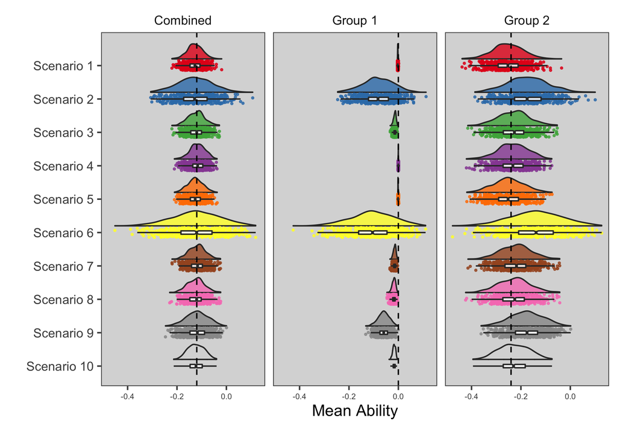

```r
knitr::include_graphics(file.path(plotPath, "Figure_raw.png"))
```

## Figure 2

Bland-Altman plots showing unstandardized data from 500 randomly selected simulated respondents per scenario. The x-axis represents the data generating $\theta_i$ values, and the y-axis represents the unstandardized residuals ($x_i - \theta_i$) broken down by group and scenario. Dashed horizontal lines are drawn at ± 0.30 raw score units from 0.

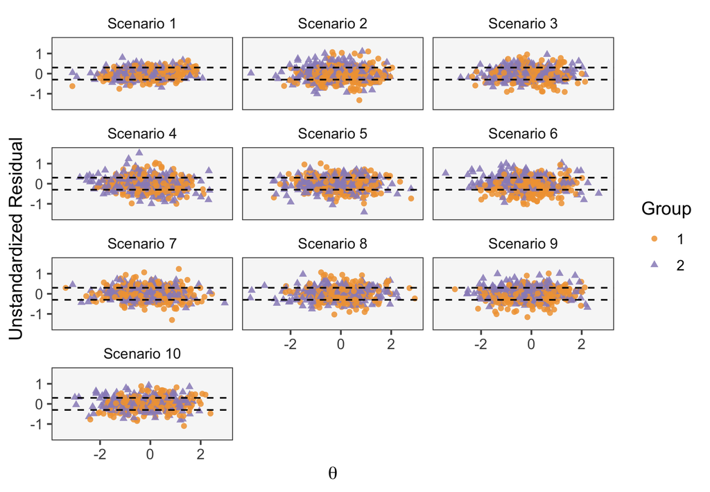

```r
knitr::include_graphics(file.path(plotPath, "BlandAltman_us.png"))
```

### Unstandardized factor score estimates outside of |.30| units in the two subgroups

```r
pandoc.table(f3dat1,
             digits = 3,
             keep.trailing.zeros = TRUE,
             split.tables = Inf,
             row.names = FALSE,
             col.names = c("Within 0.3", "Scenario", "Group", "Proportion"))
```

| Within 0.3 | Scenario | Group | Proportion |
| --- | --- | --- | --- |
| 0 | 1 | 1 | 0.125 |
| 1 | 1 | 1 | 0.875 |
| 0 | 2 | 1 | 0.143 |
| 1 | 2 | 1 | 0.857 |
| 0 | 3 | 1 | 0.179 |
| 1 | 3 | 1 | 0.821 |
| 0 | 4 | 1 | 0.201 |
| 1 | 4 | 1 | 0.799 |
| 0 | 5 | 1 | 0.174 |
| 1 | 5 | 1 | 0.826 |
| 0 | 6 | 1 | 0.137 |
| 1 | 6 | 1 | 0.863 |
| 0 | 7 | 1 | 0.178 |
| 1 | 7 | 1 | 0.822 |
| 0 | 8 | 1 | 0.180 |
| 1 | 8 | 1 | 0.820 |
| 0 | 9 | 1 | 0.150 |
| 1 | 9 | 1 | 0.850 |
| 0 | 10 | 1 | 0.151 |
| 1 | 10 | 1 | 0.849 |
| 0 | 1 | 2 | 0.113 |
| 1 | 1 | 2 | 0.887 |
| 0 | 2 | 2 | 0.244 |
| 1 | 2 | 2 | 0.756 |
| 0 | 3 | 2 | 0.160 |
| 1 | 3 | 2 | 0.840 |
| 0 | 4 | 2 | 0.203 |
| 1 | 4 | 2 | 0.797 |
| 0 | 5 | 2 | 0.168 |
| 1 | 5 | 2 | 0.832 |
| 0 | 6 | 2 | 0.283 |
| 1 | 6 | 2 | 0.717 |
| 0 | 7 | 2 | 0.168 |
| 1 | 7 | 2 | 0.832 |
| 0 | 8 | 2 | 0.161 |
| 1 | 8 | 2 | 0.839 |
| 0 | 9 | 2 | 0.231 |
| 1 | 9 | 2 | 0.769 |
| 0 | 10 | 2 | 0.159 |
| 1 | 10 | 2 | 0.841 |

### Unstandardized factor score estimates outside of |.30| units in the combined sample

```r
pandoc.table(f3dat2,
             digits = 3,
             keep.trailing.zeros = TRUE,
             split.tables = Inf,
             row.names = FALSE,
             col.names = c("Within 0.3", "Scenario", "Proportion"))
```

| Within 0.3 | Scenario | Proportion |
| --- | --- | --- |
| 0 | 1 | 0.119 |
| 1 | 1 | 0.881 |
| 0 | 2 | 0.193 |
| 1 | 2 | 0.807 |
| 0 | 3 | 0.169 |
| 1 | 3 | 0.831 |
| 0 | 4 | 0.202 |
| 1 | 4 | 0.798 |
| 0 | 5 | 0.171 |
| 1 | 5 | 0.829 |
| 0 | 6 | 0.210 |
| 1 | 6 | 0.790 |
| 0 | 7 | 0.173 |
| 1 | 7 | 0.827 |
| 0 | 8 | 0.171 |
| 1 | 8 | 0.829 |
| 0 | 9 | 0.191 |
| 1 | 9 | 0.809 |
| 0 | 10 | 0.155 |
| 1 | 10 | 0.845 |